# Pandas Fundamentals

[figure not shown]

## Use the Pandas library to do statistics on tabular data.

Pandas is a an open source library providing high-performance, easy-to-use data structures and data analysis tools. Pandas is particularly suited to the analysis of tabular data, i.e. data that can can go into a table.

### In other words, if you can imagine the data in an Excel spreadsheet, then Pandas is the tool for the job.

Pandas DataFrames are 2-dimensional tables whose columns have names and potentially have different data types.

Pandas Dataframes are pretty much like excel spreadsheets! **and excel spreadsheets are pretty much like matricies** - make Nick draw this on the board and talk throughs some examples

### installing `pandas` with (Ana)conda (if needed...)

to get `pandas` (you only need to do this the first time we go throug this):

1. go to the little `+` on the left to open a `launcher` window.
2. click the 'terminal' tile to open a terminal
3. type `conda env list` and hit enter. Make sure that there is a `*` next to the line that says swbc
4. if that's right type `conda install pandas`
5. when it asks `proceed ([y]/n)?` type `y` and hit enter

## Credit:

this comes from Abernathys open book, which we will be looking at a lot! https://earth-env-data-science.github.io/lectures/core_python/python_fundamentals.html

```python
#import numpy, matplotlib.pyplot, pandas

import pandas as pd
import numpy as np
from matplotlib import pyplot as plt
%matplotlib inline
```

## Pandas Data Structures: Series

We've seen several data structures so far: `lists` `dictionaries`, `arrays`. The Pandas labrary provides several data structures which are **super** useful.

The `Series` data structure represents a one-dimensional array of data. The main difference between a `Series` and numpy `array` is that a Series has an *index*. The index contains the labels that we use to access the data.

There are many ways to [create a Series](https://pandas.pydata.org/pandas-docs/stable/dsintro.html#series). We will just show a few.

```python
names = ['Ryan','Chiara','Johnny']
values = [36,37,2.7]
ages = pd.Series(values, index = names)
ages
```

```
Ryan      36.0
Chiara    37.0
Johnny     2.7
dtype: float64
```

If you think back to the `dictionary` you will see some similarities: namely labels (`keys` for `dict`, `index` for pandas `series`)

Series have built in plotting methods that will let you very quickly make some default plots

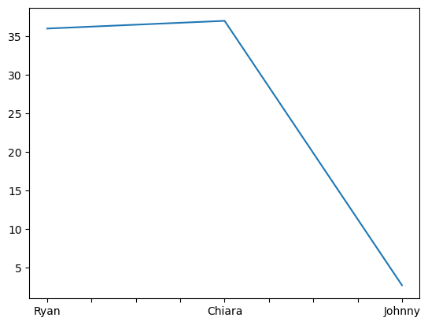

```python
ages.plot()
```

These default plots are configurable in many ways:

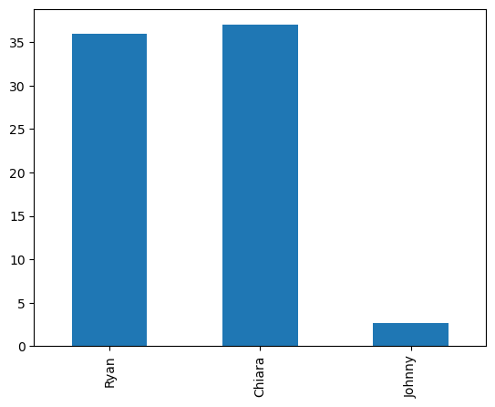

```python
#change to a bar plot
ages.plot(kind = 'bar')
```

Arithmetic operations and most numpy function can be applied to Series. An important point is that the Series keep their index during such operations.

```python
np.log(ages) / ages**2
```

```
Ryan      0.002765
Chiara    0.002638
Johnny    0.136249
dtype: float64
```

We can access the underlying `index` object if we need to by asking for the `.index` for a pandas series code object:

```python
ages.index
```

```
Index(['Ryan', 'Chiara', 'Johnny'], dtype='object')
```

### Indexing

We talked about indexing (or grabbing data from a position) before: for example we looked at the first patient data with something like `patient_0 = data[0,:]`. There we used a number to get the data position.

With pandas we can use the index to grab data. In this case the index is a bunch of names, so we can ask for the data from `Johnny` for example using the `.loc` attribute:

```python
ages.loc['Johnny']
```

```
np.float64(2.7)
```

Or we can still use the number position `.iloc`

```python
ages.iloc[2]
```

```
np.float64(2.7)
```

You can already maybe see part of why pandas is so great. What is easier to understand?

```
ages.loc['Johnny']
```

or

```
ages.iloc[2]
```

To me, being able to ask for the index using a label like `Johnny` makes the code much easier to understand, and makes my analysis more clear in my head.

We can pass a list or array to loc to get multiple rows back:

```python
ages.loc[['Ryan','Johnny']]
```

```
Ryan      36.0
Johnny     2.7
dtype: float64
```

And we can even use slice notation

```python
ages.loc['Ryan':'Johnny']
```

```
Ryan      36.0
Chiara    37.0
Johnny     2.7
dtype: float64
```

```python
ages.iloc[:2]
```

```
Ryan      36.0
Chiara    37.0
dtype: float64
```

If we need to, we can always get the raw data back out as well

```python
ages.values # a numpy array
```

```
array([36. , 37. ,  2.7])
```

```python
ages.index # a pandas Index object
```

```
Index(['Ryan', 'Chiara', 'Johnny'], dtype='object')
```

## Pandas Data Structures: DataFrame

There is a lot more to Series, but they are limited to a single "column". A more useful Pandas data structure is the `DataFrame`. A `DataFrame` is basically a **bunch of series that share the same index**. It's a lot like a table in a spreadsheet.

Below we create a DataFrame.

```python
# first we create a dictionary
data = {'age':[36,37,1.7],
        'height': [ 180, 155, 90],
        'weight': [78, np.nan, 11.3]}
df = pd.DataFrame(data, index=['Ryan','Chiara', 'Johnny'])
df
```

|  | age | height | weight |
| --- | --- | --- | --- |
| Ryan | 36.0 | 180 | 78.0 |
| Chiara | 37.0 | 155 | NaN |
| Johnny | 1.7 | 90 | 11.3 |

Pandas handles missing data very elegantly, keeping track of it through all calculations.

We can get some basic information about our `dataframe` data structure by using its `.info()` function:

```python
df.info()
```

```
<class 'pandas.core.frame.DataFrame'>
Index: 3 entries, Ryan to Johnny
Data columns (total 3 columns):
 #   Column  Non-Null Count  Dtype
---  ------  --------------  -----
 0   age     3 non-null      float64
 1   height  3 non-null      int64
 2   weight  2 non-null      float64
dtypes: float64(2), int64(1)
memory usage: 96.0+ bytes
```

A wide range of statistical functions are available on both Series and DataFrames.

```python
df.min()
```

```
age        1.7
height    90.0
weight    11.3
dtype: float64
```

```python
df.mean()
```

```
age        24.900000
height    141.666667
weight     44.650000
dtype: float64
```

```python
df.std()
```

```
age       20.098010
height    46.457866
weight    47.164022
dtype: float64
```

```python
df.describe()
```

|  | age | height | weight |
| --- | --- | --- | --- |
| count | 3.00000 | 3.000000 | 2.000000 |
| mean | 24.90000 | 141.666667 | 44.650000 |
| std | 20.09801 | 46.457866 | 47.164022 |
| min | 1.70000 | 90.000000 | 11.300000 |
| 25% | 18.85000 | 122.500000 | 27.975000 |
| 50% | 36.00000 | 155.000000 | 44.650000 |
| 75% | 36.50000 | 167.500000 | 61.325000 |
| max | 37.00000 | 180.000000 | 78.000000 |

We can get a single column as a Series using python's getitem syntax on the DataFrame object.

```python
df['height']
```

```
Ryan      180
Chiara    155
Johnny     90
Name: height, dtype: int64
```

...or using attribute syntax.

```python
df.height
```

```
Ryan      180
Chiara    155
Johnny     90
Name: height, dtype: int64
```

Indexing works very similar to series

```python
df.loc['Johnny']
```

```
age        1.7
height    90.0
weight    11.3
Name: Johnny, dtype: float64
```

```python
df.iloc[2]
```

```
age        1.7
height    90.0
weight    11.3
Name: Johnny, dtype: float64
```

But we can also specify the column we want to access

```python
df.loc['Johnny','age']
```

```
np.float64(1.7)
```

```python
df.iloc[:2, 0]
```

```
Ryan      36.0
Chiara    37.0
Name: age, dtype: float64
```

If we make a calculation using columns from the DataFrame, it will keep the same index:

```python
df.weight / df.height
```

```
Ryan      0.433333
Chiara         NaN
Johnny    0.125556
dtype: float64
```

Which we can easily add as another column to the DataFrame:

```python
df['density'] = df.weight / df.height
df
```

|  | age | height | weight | density |
| --- | --- | --- | --- | --- |
| Ryan | 36.0 | 180 | 78.0 | 0.433333 |
| Chiara | 37.0 | 155 | NaN | NaN |
| Johnny | 1.7 | 90 | 11.3 | 0.125556 |

## Merging Data

Pandas supports a wide range of methods for merging different datasets. These are described extensively in the [documentation](https://pandas.pydata.org/pandas-docs/stable/merging.html). Here we just give a few examples.

```python
education = pd.Series(['BS','PhD',None,'masters'],
                     index = ['Ryan','Chiara','Johnny','Xiaomeng'],
                     name = 'education')
education
```

```
Ryan             BS
Chiara          PhD
Johnny         None
Xiaomeng    masters
Name: education, dtype: object
```

We can add the data from the series `education` to our dataframe `df` using the function `.join()`, which will match overlapping indexes and add the new series as a column:

```python
# returns a new DataFrame
df.join(education)
```

|  | age | height | weight | density | education |
| --- | --- | --- | --- | --- | --- |
| Ryan | 36.0 | 180 | 78.0 | 0.433333 | BS |
| Chiara | 37.0 | 155 | NaN | NaN | PhD |
| Johnny | 1.7 | 90 | 11.3 | 0.125556 | None |

```python
#returns a new DataFrame
df.join(education, how = 'right')
```

|  | age | height | weight | density | education |
| --- | --- | --- | --- | --- | --- |
| Ryan | 36.0 | 180.0 | 78.0 | 0.433333 | BS |
| Chiara | 37.0 | 155.0 | NaN | NaN | PhD |
| Johnny | 1.7 | 90.0 | 11.3 | 0.125556 | None |
| Xiaomeng | NaN | NaN | NaN | NaN | masters |

We can also index using a boolean series. This is very useful

```python
adults = df[df.age > 18]
adults
```

|  | age | height | weight | density |
| --- | --- | --- | --- | --- |
| Ryan | 36.0 | 180 | 78.0 | 0.433333 |
| Chiara | 37.0 | 155 | NaN | NaN |

```python
df['is_adult'] = df.age > 18
df
```

|  | age | height | weight | density | is_adult |
| --- | --- | --- | --- | --- | --- |
| Ryan | 36.0 | 180 | 78.0 | 0.433333 | True |
| Chiara | 37.0 | 155 | NaN | NaN | True |
| Johnny | 1.7 | 90 | 11.3 | 0.125556 | False |

### Modifying Values

We often want to modify values in a dataframe based on some rule. To modify values, we need to use `.loc` or `.iloc`

```python
df.loc['Johnny', 'height'] = 95
df.loc['Ryan', 'weight'] += 1
df
```

|  | age | height | weight | density | is_adult |
| --- | --- | --- | --- | --- | --- |
| Ryan | 36.0 | 180 | 79.0 | 0.433333 | True |
| Chiara | 37.0 | 155 | NaN | NaN | True |
| Johnny | 1.7 | 95 | 11.3 | 0.125556 | False |

## Plotting

DataFrames have all kinds of [useful plotting](https://pandas.pydata.org/pandas-docs/stable/visualization.html) built in.

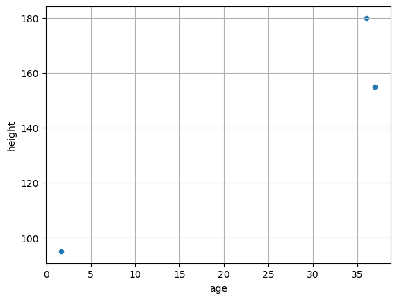

```python
df.plot(kind = 'scatter', x = 'age', y ='height', grid = True)
```

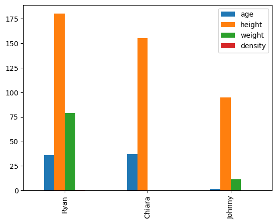

```python
df.plot(kind = 'bar')
```

Later we will dig deeper into resampling, rolling means, and grouping operations (groupby).

# more on Pandas index

## Credit:

this comes from Abernathys open book, which we will be looking at a lot! https://earth-env-data-science.github.io/lectures/core_python/python_fundamentals.html

## Time Indexes

Indexes are very powerful. They label the data inside a pandas series or dataframe and let you intuitivly work with the data. They are a big part of why Pandas is so useful. There are different indices for different types of data. Time Indexes are especially great!

```python
# import pandas, etc.
import pandas as pd
import matplotlib.pyplot as plt
import numpy as np
%matplotlib inline
```

# dates

Python has a special datatype specific to dates. Dates get treated differently than nummbers or strings, and this feature lets you do lots of powerful timeseries analysis.

Below we make a special time series using `pd.date_range()` where we can speficy the start, end and frequency of points we want

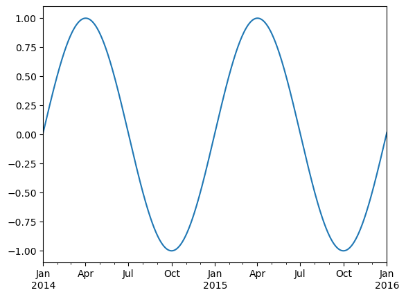

```python
two_years = pd.date_range(start='2014-01-01',end='2016-01-01',freq='D')
timeseries = pd.Series(np.sin(2*np.pi *two_years.dayofyear / 365),
                      index = two_years)
timeseries.plot()
```

What happened there? We made a range of times (data of a particular type, the pandas `datetime` type) using pandas `pd.date_range()`, then we used numpy (`np.sin()`) to make some fake data based on that time range.

I added the fake data, and the time range into a pandas `Series` called `timeseries`, which is like one column of a `DataFrame` using the function that creates series: `pd.Series()` , telling the function to used `two_years` as our index for our variable `timeseries`.

Because we used the special way pandas can create time indicies, when we plotted the `Series` using `timeseries.plot()`, matplotlib knows we are talking about time and labels everything nicely.

# indexing and slicing

Let's say we want to just get some time subset of our data. Pandas has an easy way to let us do that using the `.loc` notation we've seen before:

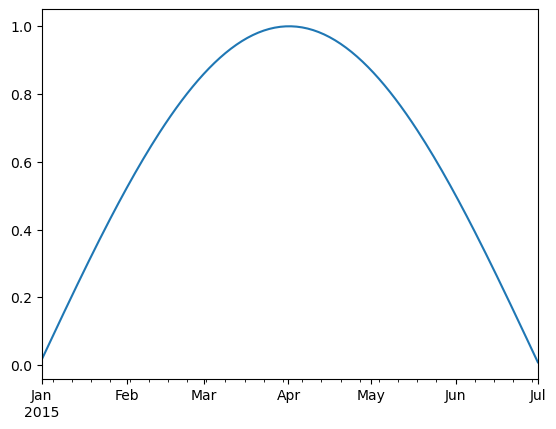

```python
timeseries.loc['2015-01-01':'2015-07-01'].plot()
```

The TimeIndex object has lots of useful attributes

```python
timeseries.index.month
```

```
Index([ 1,  1,  1,  1,  1,  1,  1,  1,  1,  1,
       ...
       12, 12, 12, 12, 12, 12, 12, 12, 12,  1],
      dtype='int32', length=731)
```

```python
timeseries.index.day
```

```
Index([ 1,  2,  3,  4,  5,  6,  7,  8,  9, 10,
       ...
       23, 24, 25, 26, 27, 28, 29, 30, 31,  1],
      dtype='int32', length=731)
```

## Reading real Data Files: NOAA Weather Station Data

In this example, we will use NOAA weather station data from https://www.ncdc.noaa.gov/data-access/land-based-station-data.

We have a text file on our hard drive called `data.txt`. **Examine it by opening in jupyterlab.** What do you see?

To read it into pandas, we will use the [read_csv](https://pandas.pydata.org/pandas-docs/stable/generated/pandas.read_csv.html) function. This function is incredibly complex and powerful. You can use it to extract data from almost any text file. However, you need to understand how to use its various options. Its is awesome, it will let you read data out of almost any text file. However to get the data in a useful format we are going to have to do a few things to it. In the next few steps we will see how to clean and wrangle the data into a good format for use.

### Cleaning and wrangling messy data into a format you can use is an incredibly important skill to master

If we just read the data in with no options, we get something that is a bit of a mess:

With no options, this is what we get.

```python
df = pd.read_csv('./data/data.txt')

print(df.shape)
df.head()
```

```
(365, 1)
```

|  | WBANNO LST_DATE CRX_VN LONGITUDE LATITUDE T_DAILY_MAX T_DAILY_MIN T_DAILY_MEAN T_DAILY_AVG P_DAILY_CALC SOLARAD_DAILY SUR_TEMP_DAILY_TYPE SUR_TEMP_DAILY_MAX SUR_TEMP_DAILY_MIN SUR_TEMP_DAILY_AVG RH_DA… |
| --- | --- |
| 0 | 64756 20170101 2.422 -73.74 41.79 6.6 ... |
| 1 | 64756 20170102 2.422 -73.74 41.79 4.0 ... |
| 2 | 64756 20170103 2.422 -73.74 41.79 4.9 ... |
| 3 | 64756 20170104 2.422 -73.74 41.79 8.7 ... |
| 4 | 64756 20170105 2.422 -73.74 41.79 -0.5 ... |

Pandas wasn't able to automatically sort out all the columns because, as the name suggests, `pd.read_csv()` expects the data to be in comma separated value (csv) format. Our data is just separated by spaces.

Fortunatly we can put options into `pd.read_csv()` to tell it what the separation between data is by using the `sep=` keyword. This lets the function read the data correctly. The representation of space is `r'\s+'`.

```python
df = pd.read_csv('./data/data.txt', sep=r'\s+')
df
```

|  | WBANNO | LST_DATE | CRX_VN | LONGITUDE | LATITUDE | T_DAILY_MAX | T_DAILY_MIN | T_DAILY_MEAN | T_DAILY_AVG | P_DAILY_CALC | ... | SOIL_MOISTURE_5_DAILY | SOIL_MOISTURE_10_DAILY | SOIL_MOISTURE_20_DAILY | SOIL_MOISTURE_50_DAILY | SOIL_MOISTURE_100_DAILY | SOIL_TEMP_5_DAILY | SOIL_TEMP_10_DAILY | SOIL_TEMP_20_DAILY | SOIL_TEMP_50_DAILY | SOIL_TEMP_100_DAILY |
| --- | --- | --- | --- | --- | --- | --- | --- | --- | --- | --- | --- | --- | --- | --- | --- | --- | --- | --- | --- | --- | --- |
| 0 | 64756 | 20170101 | 2.422 | -73.74 | 41.79 | 6.6 | -5.4 | 0.6 | 2.2 | 0.0 | ... | -99.000 | -99.000 | 0.207 | 0.152 | 0.175 | -0.1 | 0.0 | 0.6 | 1.5 | 3.4 |
| 1 | 64756 | 20170102 | 2.422 | -73.74 | 41.79 | 4.0 | -6.8 | -1.4 | -1.2 | 0.0 | ... | -99.000 | -99.000 | 0.205 | 0.151 | 0.173 | -0.2 | 0.0 | 0.6 | 1.5 | 3.3 |
| 2 | 64756 | 20170103 | 2.422 | -73.74 | 41.79 | 4.9 | 0.7 | 2.8 | 2.7 | 13.1 | ... | -99.000 | -99.000 | 0.205 | 0.150 | 0.173 | -0.1 | 0.0 | 0.5 | 1.5 | 3.3 |
| 3 | 64756 | 20170104 | 2.422 | -73.74 | 41.79 | 8.7 | -1.6 | 3.6 | 3.5 | 1.3 | ... | -99.000 | -99.000 | 0.215 | 0.153 | 0.174 | -0.1 | 0.0 | 0.5 | 1.5 | 3.2 |
| 4 | 64756 | 20170105 | 2.422 | -73.74 | 41.79 | -0.5 | -4.6 | -2.5 | -2.8 | 0.0 | ... | -99.000 | -99.000 | 0.215 | 0.154 | 0.177 | -0.1 | 0.0 | 0.5 | 1.4 | 3.1 |
| ... | ... | ... | ... | ... | ... | ... | ... | ... | ... | ... | ... | ... | ... | ... | ... | ... | ... | ... | ... | ... | ... |
| 360 | 64756 | 20171227 | 2.622 | -73.74 | 41.79 | -6.7 | -19.3 | -13.0 | -12.9 | 0.0 | ... | 0.228 | 0.223 | 0.180 | 0.157 | 0.174 | 0.8 | 0.8 | 1.7 | 3.0 | 4.9 |
| 361 | 64756 | 20171228 | 2.622 | -73.74 | 41.79 | -10.3 | -21.5 | -15.9 | -15.8 | 0.0 | ... | 0.231 | 0.229 | 0.176 | 0.155 | 0.172 | 0.4 | 0.5 | 1.4 | 2.7 | 4.7 |
| 362 | 64756 | 20171229 | 2.622 | -73.74 | 41.79 | -9.4 | -19.0 | -14.2 | -14.7 | 0.0 | ... | -99.000 | -99.000 | 0.172 | 0.154 | 0.172 | 0.2 | 0.3 | 1.1 | 2.5 | 4.5 |
| 363 | 64756 | 20171230 | 2.622 | -73.74 | 41.79 | -7.1 | -18.9 | -13.0 | -13.6 | 1.1 | ... | -99.000 | -99.000 | 0.168 | 0.152 | 0.171 | 0.1 | 0.1 | 0.9 | 2.3 | 4.3 |
| 364 | 64756 | 20171231 | 2.622 | -73.74 | 41.79 | -12.3 | -21.8 | -17.0 | -16.7 | 0.0 | ... | -99.000 | -99.000 | 0.164 | 0.151 | 0.171 | -0.1 | 0.0 | 0.8 | 2.1 | 4.1 |

365 rows × 28 columns

excellent, much better. now the columns are all separated out well.

if we looked at all the data we will see there are lots of -99 and -9999 values in the file. If we look closely, we will see there are lots of -99 and -9999 values in the file. The README file tells us that these are values used to represent missing data. Let's tell this to pandas. We do this using an arguement specification `na_values =[listof bad data values]`. the `na` part stands for NaN (not a number) which will be filled in:

```python
df = pd.read_csv('./data/data.txt',sep=r'\s+', na_values = [-9999.0, -99.0])
df.head()
```

|  | WBANNO | LST_DATE | CRX_VN | LONGITUDE | LATITUDE | T_DAILY_MAX | T_DAILY_MIN | T_DAILY_MEAN | T_DAILY_AVG | P_DAILY_CALC | ... | SOIL_MOISTURE_5_DAILY | SOIL_MOISTURE_10_DAILY | SOIL_MOISTURE_20_DAILY | SOIL_MOISTURE_50_DAILY | SOIL_MOISTURE_100_DAILY | SOIL_TEMP_5_DAILY | SOIL_TEMP_10_DAILY | SOIL_TEMP_20_DAILY | SOIL_TEMP_50_DAILY | SOIL_TEMP_100_DAILY |
| --- | --- | --- | --- | --- | --- | --- | --- | --- | --- | --- | --- | --- | --- | --- | --- | --- | --- | --- | --- | --- | --- |
| 0 | 64756 | 20170101 | 2.422 | -73.74 | 41.79 | 6.6 | -5.4 | 0.6 | 2.2 | 0.0 | ... | NaN | NaN | 0.207 | 0.152 | 0.175 | -0.1 | 0.0 | 0.6 | 1.5 | 3.4 |
| 1 | 64756 | 20170102 | 2.422 | -73.74 | 41.79 | 4.0 | -6.8 | -1.4 | -1.2 | 0.0 | ... | NaN | NaN | 0.205 | 0.151 | 0.173 | -0.2 | 0.0 | 0.6 | 1.5 | 3.3 |
| 2 | 64756 | 20170103 | 2.422 | -73.74 | 41.79 | 4.9 | 0.7 | 2.8 | 2.7 | 13.1 | ... | NaN | NaN | 0.205 | 0.150 | 0.173 | -0.1 | 0.0 | 0.5 | 1.5 | 3.3 |
| 3 | 64756 | 20170104 | 2.422 | -73.74 | 41.79 | 8.7 | -1.6 | 3.6 | 3.5 | 1.3 | ... | NaN | NaN | 0.215 | 0.153 | 0.174 | -0.1 | 0.0 | 0.5 | 1.5 | 3.2 |
| 4 | 64756 | 20170105 | 2.422 | -73.74 | 41.79 | -0.5 | -4.6 | -2.5 | -2.8 | 0.0 | ... | NaN | NaN | 0.215 | 0.154 | 0.177 | -0.1 | 0.0 | 0.5 | 1.4 | 3.1 |

5 rows × 28 columns

ok, another good step. Now all the bad data is represented by `NaN`, which is something that pandas and numpy are good at dealing with.

you can see we are slowing bulding up a good dataframe. We are cleaning out all the warts in the data. This is something you will do over and over!

Let's check out what is in our Dataframe:

```python
df.info()
```

```
<class 'pandas.core.frame.DataFrame'>
RangeIndex: 365 entries, 0 to 364
Data columns (total 28 columns):
 #   Column                   Non-Null Count  Dtype
---  ------                   --------------  -----
 0   WBANNO                   365 non-null    int64
 1   LST_DATE                 365 non-null    int64
 2   CRX_VN                   365 non-null    float64
 3   LONGITUDE                365 non-null    float64
 4   LATITUDE                 365 non-null    float64
 5   T_DAILY_MAX              364 non-null    float64
 6   T_DAILY_MIN              364 non-null    float64
 7   T_DAILY_MEAN             364 non-null    float64
 8   T_DAILY_AVG              364 non-null    float64
 9   P_DAILY_CALC             364 non-null    float64
```

[output cut: 20 more lines]

One problem here is that pandas did not recognize the `LDT_DATE` column as a date. Let's help it.

```python
df = pd.read_csv('./data/data.txt', sep=r'\s+',
                na_values = [-9999.0, -99.0],
                parse_dates=[1])
df.info()
```

```
<class 'pandas.core.frame.DataFrame'>
RangeIndex: 365 entries, 0 to 364
Data columns (total 28 columns):
 #   Column                   Non-Null Count  Dtype
---  ------                   --------------  -----
 0   WBANNO                   365 non-null    int64
 1   LST_DATE                 365 non-null    datetime64[ns]
 2   CRX_VN                   365 non-null    float64
 3   LONGITUDE                365 non-null    float64
 4   LATITUDE                 365 non-null    float64
 5   T_DAILY_MAX              364 non-null    float64
 6   T_DAILY_MIN              364 non-null    float64
 7   T_DAILY_MEAN             364 non-null    float64
 8   T_DAILY_AVG              364 non-null    float64
 9   P_DAILY_CALC             364 non-null    float64
```

[output cut: 20 more lines]

```python
df = df.drop('SUR_TEMP_DAILY_TYPE', axis = 1)
df.info()
```

```
<class 'pandas.core.frame.DataFrame'>
RangeIndex: 365 entries, 0 to 364
Data columns (total 27 columns):
 #   Column                   Non-Null Count  Dtype
---  ------                   --------------  -----
 0   WBANNO                   365 non-null    int64
 1   LST_DATE                 365 non-null    datetime64[ns]
 2   CRX_VN                   365 non-null    float64
 3   LONGITUDE                365 non-null    float64
 4   LATITUDE                 365 non-null    float64
 5   T_DAILY_MAX              364 non-null    float64
 6   T_DAILY_MIN              364 non-null    float64
 7   T_DAILY_MEAN             364 non-null    float64
 8   T_DAILY_AVG              364 non-null    float64
 9   P_DAILY_CALC             364 non-null    float64
```

[output cut: 19 more lines]

now we see that the `LST_DATE` column is the special datetime64 type of data that lets pandas do all the cool stuff with time.

We are one step closer to a good data set!

the last step: we want to use the date as the index for our dataframe. It's the timestamp that ties all this data together. We can tell pandas to do this too by setting the index of our dataframe to that column

```python
df = df.set_index('LST_DATE')
df.index
```

```
DatetimeIndex(['2017-01-01', '2017-01-02', '2017-01-03', '2017-01-04',
               '2017-01-05', '2017-01-06', '2017-01-07', '2017-01-08',
               '2017-01-09', '2017-01-10',
               ...
               '2017-12-22', '2017-12-23', '2017-12-24', '2017-12-25',
               '2017-12-26', '2017-12-27', '2017-12-28', '2017-12-29',
               '2017-12-30', '2017-12-31'],
              dtype='datetime64[ns]', name='LST_DATE', length=365, freq=None)
```

Now we can take advantage of all the cool time stuff that pandas can do.

Like let's use indexing to look at all the data from one day

```python
df.loc['2017-08-07']
```

```
WBANNO                     64756.000
CRX_VN                         2.422
LONGITUDE                    -73.740
LATITUDE                      41.790
T_DAILY_MAX                   19.300
T_DAILY_MIN                   12.300
T_DAILY_MEAN                  15.800
T_DAILY_AVG                   16.300
P_DAILY_CALC                   4.900
SOLARAD_DAILY                  3.930
SUR_TEMP_DAILY_MAX            22.300
SUR_TEMP_DAILY_MIN            11.900
SUR_TEMP_DAILY_AVG            17.700
RH_DAILY_MAX                  94.700
RH_DAILY_MIN                  76.400
RH_DAILY_AVG                  89.500
SOIL_MOISTURE_5_DAILY          0.148
SOIL_MOISTURE_10_DAILY         0.113
SOIL_MOISTURE_20_DAILY         0.094
SOIL_MOISTURE_50_DAILY         0.114
SOIL_MOISTURE_100_DAILY        0.151
SOIL_TEMP_5_DAILY             21.400
SOIL_TEMP_10_DAILY            21.700
SOIL_TEMP_20_DAILY            22.100
SOIL_TEMP_50_DAILY            22.200
SOIL_TEMP_100_DAILY           21.500
Name: 2017-08-07 00:00:00, dtype: float64
```

Or use slicing to get a range:

```python
df.loc['2017-07-01':'2017-07-31']
```

| LST_DATE | WBANNO | CRX_VN | LONGITUDE | LATITUDE | T_DAILY_MAX | T_DAILY_MIN | T_DAILY_MEAN | T_DAILY_AVG | P_DAILY_CALC | SOLARAD_DAILY | ... | SOIL_MOISTURE_5_DAILY | SOIL_MOISTURE_10_DAILY | SOIL_MOISTURE_20_DAILY | SOIL_MOISTURE_50_DAILY | SOIL_MOISTURE_100_DAILY | SOIL_TEMP_5_DAILY | SOIL_TEMP_10_DAILY | SOIL_TEMP_20_DAILY | SOIL_TEMP_50_DAILY | SOIL_TEMP_100_DAILY |
| --- | --- | --- | --- | --- | --- | --- | --- | --- | --- | --- | --- | --- | --- | --- | --- | --- | --- | --- | --- | --- | --- |
| 2017-07-01 | 64756 | 2.422 | -73.74 | 41.79 | 28.0 | 19.7 | 23.9 | 23.8 | 0.2 | 19.28 | ... | 0.157 | 0.136 | 0.144 | 0.129 | 0.163 | 25.7 | 25.4 | 23.7 | 21.9 | 19.9 |
| 2017-07-02 | 64756 | 2.422 | -73.74 | 41.79 | 29.8 | 18.4 | 24.1 | 23.7 | 4.0 | 27.67 | ... | 0.146 | 0.135 | 0.143 | 0.129 | 0.162 | 26.8 | 26.4 | 24.5 | 22.3 | 20.1 |
| 2017-07-03 | 64756 | 2.422 | -73.74 | 41.79 | 28.3 | 15.0 | 21.7 | 21.4 | 0.0 | 27.08 | ... | 0.141 | 0.132 | 0.139 | 0.128 | 0.162 | 26.4 | 26.3 | 24.8 | 22.8 | 20.3 |
| 2017-07-04 | 64756 | 2.422 | -73.74 | 41.79 | 26.8 | 12.6 | 19.7 | 20.0 | 0.0 | 29.45 | ... | 0.131 | 0.126 | 0.136 | 0.126 | 0.161 | 25.9 | 25.8 | 24.6 | 22.9 | 20.6 |
| 2017-07-05 | 64756 | 2.422 | -73.74 | 41.79 | 28.0 | 11.9 | 20.0 | 20.7 | 0.0 | 26.90 | ... | 0.116 | 0.114 | 0.131 | 0.125 | 0.161 | 25.3 | 25.3 | 24.2 | 22.8 | 20.7 |
| 2017-07-06 | 64756 | 2.422 | -73.74 | 41.79 | 25.7 | 14.3 | 20.0 | 20.3 | 0.0 | 19.03 | ... | 0.105 | 0.104 | 0.126 | 0.124 | 0.160 | 24.7 | 24.7 | 23.9 | 22.7 | 20.9 |
| 2017-07-07 | 64756 | 2.422 | -73.74 | 41.79 | 25.8 | 16.8 | 21.3 | 20.0 | 11.5 | 13.88 | ... | 0.114 | 0.100 | 0.123 | 0.123 | 0.160 | 24.2 | 24.2 | 23.4 | 22.4 | 20.8 |
| 2017-07-08 | 64756 | 2.422 | -73.74 | 41.79 | 29.0 | 15.3 | 22.1 | 21.5 | 0.0 | 21.92 | ... | 0.130 | 0.106 | 0.122 | 0.123 | 0.159 | 25.5 | 25.3 | 23.9 | 22.4 | 20.8 |
| 2017-07-09 | 64756 | 2.422 | -73.74 | 41.79 | 26.3 | 10.9 | 18.6 | 19.4 | 0.0 | 29.72 | ... | 0.119 | 0.103 | 0.119 | 0.121 | 0.158 | 24.8 | 24.8 | 23.8 | 22.5 | 20.8 |
| 2017-07-10 | 64756 | 2.422 | -73.74 | 41.79 | 27.6 | 11.8 | 19.7 | 21.3 | 0.0 | 23.67 | ... | 0.105 | 0.096 | 0.113 | 0.120 | 0.158 | 24.7 | 24.7 | 23.6 | 22.5 | 20.9 |
| 2017-07-11 | 64756 | 2.422 | -73.74 | 41.79 | 27.4 | 19.2 | 23.3 | 22.6 | 8.5 | 17.79 | ... | 0.106 | 0.093 | 0.110 | 0.120 | 0.157 | 25.6 | 25.4 | 24.1 | 22.6 | 20.9 |
| 2017-07-12 | 64756 | 2.422 | -73.74 | 41.79 | 29.4 | 18.5 | 23.9 | 23.1 | 1.9 | 16.27 | ... | 0.108 | 0.094 | 0.108 | 0.118 | 0.157 | 25.8 | 25.6 | 24.2 | 22.8 | 21.0 |
| 2017-07-13 | 64756 | 2.422 | -73.74 | 41.79 | 29.5 | 18.3 | 23.9 | 23.4 | 23.3 | 13.61 | ... | 0.134 | 0.110 | 0.108 | 0.118 | 0.156 | 25.7 | 25.7 | 24.4 | 23.0 | 21.0 |
| 2017-07-14 | 64756 | 2.422 | -73.74 | 41.79 | 18.5 | 15.9 | 17.2 | 17.5 | 4.1 | 5.36 | ... | 0.194 | 0.151 | 0.114 | 0.120 | 0.155 | 23.0 | 23.3 | 23.4 | 22.9 | 21.2 |
| 2017-07-15 | 64756 | 2.422 | -73.74 | 41.79 | 26.6 | 16.5 | 21.5 | 21.0 | 0.8 | 21.13 | ... | 0.190 | 0.163 | 0.119 | 0.122 | 0.155 | 24.6 | 24.4 | 23.2 | 22.2 | 21.2 |
| 2017-07-16 | 64756 | 2.422 | -73.74 | 41.79 | 27.9 | 13.3 | 20.6 | 21.0 | 0.0 | 27.03 | ... | 0.171 | 0.154 | 0.123 | 0.123 | 0.155 | 25.4 | 25.3 | 23.9 | 22.6 | 21.1 |
| 2017-07-17 | 64756 | 2.422 | -73.74 | 41.79 | 29.2 | 16.1 | 22.6 | 22.9 | 0.0 | 20.47 | ... | 0.155 | 0.143 | 0.124 | 0.122 | 0.156 | 25.7 | 25.6 | 24.4 | 22.9 | 21.2 |
| 2017-07-18 | 64756 | 2.422 | -73.74 | 41.79 | 30.3 | 19.3 | 24.8 | 24.7 | 0.0 | 24.99 | ... | 0.142 | 0.132 | 0.122 | 0.122 | 0.156 | 27.0 | 26.7 | 24.9 | 23.2 | 21.3 |
| 2017-07-19 | 64756 | 2.422 | -73.74 | 41.79 | 31.2 | 19.1 | 25.1 | 25.0 | 0.0 | 27.69 | ... | 0.126 | 0.118 | 0.118 | 0.122 | 0.156 | 27.6 | 27.4 | 25.6 | 23.7 | 21.5 |
| 2017-07-20 | 64756 | 2.422 | -73.74 | 41.79 | 31.8 | 16.6 | 24.2 | 23.4 | 0.7 | 21.53 | ... | 0.111 | 0.103 | 0.114 | 0.121 | 0.156 | 27.0 | 27.0 | 25.6 | 24.0 | 21.7 |
| 2017-07-21 | 64756 | 2.422 | -73.74 | 41.79 | 30.6 | 16.6 | 23.6 | 23.6 | 0.0 | 25.55 | ... | 0.100 | 0.093 | 0.108 | 0.120 | 0.155 | 27.1 | 27.0 | 25.5 | 24.0 | 21.9 |
| 2017-07-22 | 64756 | 2.422 | -73.74 | 41.79 | 27.7 | 15.6 | 21.7 | 21.2 | 0.5 | 16.04 | ... | 0.092 | 0.086 | 0.104 | 0.119 | 0.156 | 25.9 | 26.1 | 25.3 | 24.1 | 22.0 |
| 2017-07-23 | 64756 | 2.422 | -73.74 | 41.79 | 26.4 | 18.5 | 22.5 | 22.2 | 0.0 | 19.03 | ... | 0.087 | 0.082 | 0.100 | 0.118 | 0.155 | 26.0 | 26.0 | 24.9 | 23.8 | 22.1 |
| 2017-07-24 | 64756 | 2.422 | -73.74 | 41.79 | 19.4 | 14.8 | 17.1 | 16.7 | 29.2 | 9.10 | ... | 0.145 | 0.118 | 0.102 | 0.117 | 0.154 | 23.1 | 23.6 | 23.9 | 23.5 | 22.1 |
| 2017-07-25 | 64756 | 2.422 | -73.74 | 41.79 | 18.6 | 13.7 | 16.2 | 16.2 | 0.0 | 7.35 | ... | 0.167 | 0.133 | 0.107 | 0.116 | 0.153 | 21.9 | 22.2 | 22.4 | 22.5 | 21.9 |
| 2017-07-26 | 64756 | 2.422 | -73.74 | 41.79 | 24.7 | 11.2 | 18.0 | 18.3 | 0.0 | 22.22 | ... | 0.155 | 0.128 | 0.108 | 0.118 | 0.152 | 22.9 | 23.0 | 22.3 | 22.0 | 21.7 |
| 2017-07-27 | 64756 | 2.422 | -73.74 | 41.79 | 24.2 | 15.2 | 19.7 | 19.5 | 0.0 | 8.28 | ... | 0.144 | 0.122 | 0.109 | 0.118 | 0.154 | 22.5 | 22.7 | 22.4 | 22.0 | 21.4 |
| 2017-07-28 | 64756 | 2.422 | -73.74 | 41.79 | 26.5 | 16.9 | 21.7 | 20.9 | 0.0 | 21.06 | ... | 0.137 | 0.117 | 0.110 | 0.119 | 0.154 | 24.1 | 24.1 | 22.8 | 22.0 | 21.3 |
| 2017-07-29 | 64756 | 2.422 | -73.74 | 41.79 | 24.2 | 10.4 | 17.3 | 18.1 | 0.0 | 21.28 | ... | 0.126 | 0.108 | 0.108 | 0.118 | 0.154 | 23.3 | 23.6 | 23.0 | 22.2 | 21.3 |
| 2017-07-30 | 64756 | 2.422 | -73.74 | 41.79 | 25.5 | 8.2 | 16.8 | 17.3 | 0.0 | 27.68 | ... | 0.113 | 0.099 | 0.104 | 0.117 | 0.154 | 22.8 | 23.0 | 22.4 | 22.0 | 21.3 |
| 2017-07-31 | 64756 | 2.422 | -73.74 | 41.79 | 29.4 | 10.1 | 19.7 | 20.1 | 0.0 | 25.49 | ... | 0.101 | 0.090 | 0.099 | 0.116 | 0.153 | 23.8 | 23.8 | 22.7 | 21.9 | 21.2 |

31 rows × 26 columns

### Quick Statistics

```python
df.describe()
```

|  | WBANNO | CRX_VN | LONGITUDE | LATITUDE | T_DAILY_MAX | T_DAILY_MIN | T_DAILY_MEAN | T_DAILY_AVG | P_DAILY_CALC | SOLARAD_DAILY | ... | SOIL_MOISTURE_5_DAILY | SOIL_MOISTURE_10_DAILY | SOIL_MOISTURE_20_DAILY | SOIL_MOISTURE_50_DAILY | SOIL_MOISTURE_100_DAILY | SOIL_TEMP_5_DAILY | SOIL_TEMP_10_DAILY | SOIL_TEMP_20_DAILY | SOIL_TEMP_50_DAILY | SOIL_TEMP_100_DAILY |
| --- | --- | --- | --- | --- | --- | --- | --- | --- | --- | --- | --- | --- | --- | --- | --- | --- | --- | --- | --- | --- | --- |
| count | 365.0 | 365.000000 | 3.650000e+02 | 3.650000e+02 | 364.000000 | 364.000000 | 364.000000 | 364.000000 | 364.000000 | 364.000000 | ... | 317.000000 | 317.000000 | 336.000000 | 364.000000 | 359.000000 | 364.000000 | 364.000000 | 364.000000 | 364.000000 | 364.000000 |
| mean | 64756.0 | 2.470767 | -7.374000e+01 | 4.179000e+01 | 15.720055 | 4.037912 | 9.876374 | 9.990110 | 2.797802 | 13.068187 | ... | 0.183804 | 0.181000 | 0.156533 | 0.138286 | 0.162844 | 12.344231 | 12.308516 | 12.060989 | 11.960989 | 11.971978 |
| std | 0.0 | 0.085997 | 5.265234e-13 | 3.842198e-13 | 10.502087 | 9.460676 | 9.727451 | 9.619168 | 7.238628 | 7.953074 | ... | 0.047493 | 0.052697 | 0.042775 | 0.019207 | 0.013814 | 9.367742 | 9.350273 | 8.760899 | 8.082595 | 7.170197 |
| min | 64756.0 | 2.422000 | -7.374000e+01 | 4.179000e+01 | -12.300000 | -21.800000 | -17.000000 | -16.700000 | 0.000000 | 0.100000 | ... | 0.075000 | 0.074000 | 0.069000 | 0.100000 | 0.128000 | -0.700000 | -0.400000 | 0.200000 | 0.900000 | 1.900000 |
| 25% | 64756.0 | 2.422000 | -7.374000e+01 | 4.179000e+01 | 6.900000 | -2.775000 | 2.100000 | 2.275000 | 0.000000 | 6.225000 | ... | 0.148000 | 0.137000 | 0.118000 | 0.118000 | 0.155000 | 2.275000 | 2.075000 | 2.575000 | 3.300000 | 4.100000 |
| 50% | 64756.0 | 2.422000 | -7.374000e+01 | 4.179000e+01 | 17.450000 | 4.350000 | 10.850000 | 11.050000 | 0.000000 | 12.865000 | ... | 0.192000 | 0.198000 | 0.169000 | 0.147000 | 0.166000 | 13.300000 | 13.350000 | 13.100000 | 12.850000 | 11.650000 |
| 75% | 64756.0 | 2.422000 | -7.374000e+01 | 4.179000e+01 | 24.850000 | 11.900000 | 18.150000 | 18.450000 | 1.400000 | 19.740000 | ... | 0.221000 | 0.219000 | 0.188000 | 0.152250 | 0.173000 | 21.025000 | 21.125000 | 20.400000 | 19.800000 | 19.325000 |
| max | 64756.0 | 2.622000 | -7.374000e+01 | 4.179000e+01 | 33.400000 | 20.700000 | 25.700000 | 26.700000 | 65.700000 | 29.910000 | ... | 0.294000 | 0.321000 | 0.231000 | 0.170000 | 0.192000 | 27.600000 | 27.400000 | 25.600000 | 24.100000 | 22.100000 |

8 rows × 26 columns

### Plotting Values

We can now quickly make plots of the data

Pandas is very "time aware":

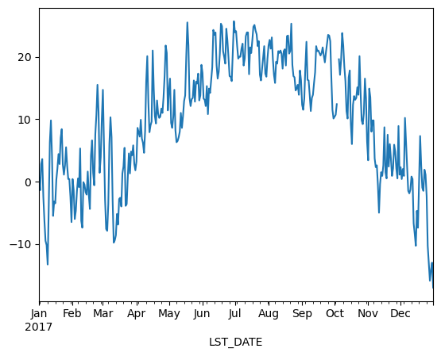

```python
df.T_DAILY_MEAN.plot()
```

Note: we could also manually create an axis and plot into it.

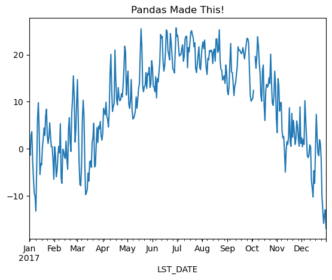

```python
fig,ax = plt.subplots()
df.T_DAILY_MEAN.plot(ax=ax)
ax.set_title('Pandas Made This!')
```

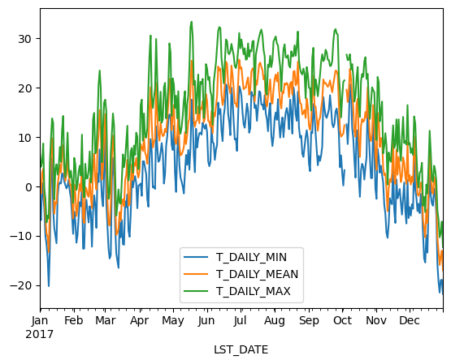

```python
df[['T_DAILY_MIN', 'T_DAILY_MEAN', 'T_DAILY_MAX']].plot()
```

We can do some statistrical plots too:

[output not shown]

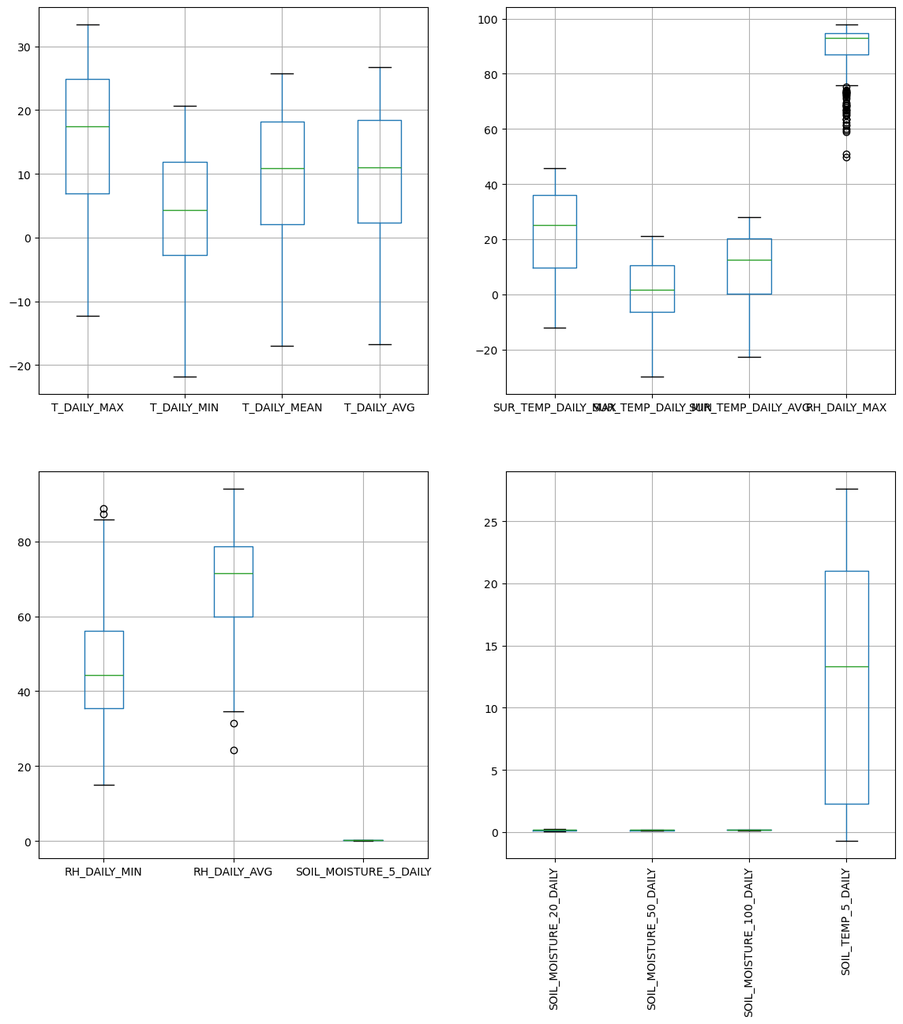

```python
fig, ax = plt.subplots(ncols = 2, nrows = 2, figsize = (14,14))

df.iloc[:,4:8].boxplot(ax=ax[0,0])
df.iloc[:,10:14].boxplot(ax=ax[0,1])
df.iloc[:,14:17].boxplot(ax=ax[1,0])
df.iloc[:, 18:22].boxplot(ax=ax[1,1])

ax[1,1].set_xticklabels(ax[1,1].get_xticklabels(),rotation=90)
```

# Resampling

Pandas understands how to do all sorts of time related things. It has many methods that let us manipulate timeseries in useful ways.

For example there is a method called resampling that oranizes the data based on a different time bin than the origional data.

Let's resample from daily to monthly data:

```python
# monthly resampler object
rs_obj = df.resample('ME')
rs_obj
```

```
<pandas.core.resample.DatetimeIndexResampler object at 0x185ce2e40>
```

The output of the `.resample()` function is an object where the data has been storted into bins where all the data in a bin come from the same month. We then need to do some calculation on that bin to get a vaule. THis is a `groupby` - type operation.  we can use this to get monthly-means of all the data

```python
rs_obj.mean()
```

| LST_DATE | WBANNO | CRX_VN | LONGITUDE | LATITUDE | T_DAILY_MAX | T_DAILY_MIN | T_DAILY_MEAN | T_DAILY_AVG | P_DAILY_CALC | SOLARAD_DAILY | ... | SOIL_MOISTURE_5_DAILY | SOIL_MOISTURE_10_DAILY | SOIL_MOISTURE_20_DAILY | SOIL_MOISTURE_50_DAILY | SOIL_MOISTURE_100_DAILY | SOIL_TEMP_5_DAILY | SOIL_TEMP_10_DAILY | SOIL_TEMP_20_DAILY | SOIL_TEMP_50_DAILY | SOIL_TEMP_100_DAILY |
| --- | --- | --- | --- | --- | --- | --- | --- | --- | --- | --- | --- | --- | --- | --- | --- | --- | --- | --- | --- | --- | --- |
| 2017-01-31 | 64756.0 | 2.422000 | -73.74 | 41.79 | 3.945161 | -3.993548 | -0.025806 | 0.038710 | 3.090323 | 4.690000 | ... | 0.236900 | 0.248300 | 0.204550 | 0.152806 | 0.175194 | 0.209677 | 0.267742 | 0.696774 | 1.438710 | 2.877419 |
| 2017-02-28 | 64756.0 | 2.422000 | -73.74 | 41.79 | 7.246429 | -4.360714 | 1.442857 | 1.839286 | 2.414286 | 10.364286 | ... | 0.226333 | 0.243000 | 0.207545 | 0.152857 | 0.175786 | 1.125000 | 1.100000 | 1.192857 | 1.492857 | 2.367857 |
| 2017-03-31 | 64756.0 | 2.422000 | -73.74 | 41.79 | 5.164516 | -5.335484 | -0.090323 | 0.167742 | 3.970968 | 13.113548 | ... | 0.218033 | 0.229267 | 0.196258 | 0.153484 | 0.174548 | 2.122581 | 2.161290 | 2.345161 | 2.700000 | 3.387097 |
| 2017-04-30 | 64756.0 | 2.422000 | -73.74 | 41.79 | 17.813333 | 5.170000 | 11.493333 | 11.540000 | 2.300000 | 14.645000 | ... | 0.199733 | 0.210300 | 0.190667 | 0.151000 | 0.172400 | 11.066667 | 10.666667 | 9.636667 | 8.426667 | 6.903333 |
| 2017-05-31 | 64756.0 | 2.422000 | -73.74 | 41.79 | 19.151613 | 7.338710 | 13.229032 | 13.638710 | 4.141935 | 16.519677 | ... | 0.206613 | 0.210935 | 0.185613 | 0.147710 | 0.170000 | 16.454839 | 16.290323 | 15.361290 | 14.270968 | 12.696774 |
| 2017-06-30 | 64756.0 | 2.422000 | -73.74 | 41.79 | 25.423333 | 12.176667 | 18.796667 | 18.986667 | 3.743333 | 21.655000 | ... | 0.185167 | 0.184300 | 0.173167 | 0.142533 | 0.167000 | 22.350000 | 22.166667 | 20.880000 | 19.370000 | 17.333333 |
| 2017-07-31 | 64756.0 | 2.422000 | -73.74 | 41.79 | 26.912903 | 15.183871 | 21.048387 | 20.993548 | 2.732258 | 20.566129 | ... | 0.131226 | 0.115774 | 0.116613 | 0.121032 | 0.156677 | 24.993548 | 24.980645 | 23.925806 | 22.745161 | 21.164516 |
| 2017-08-31 | 64756.0 | 2.422000 | -73.74 | 41.79 | 25.741935 | 12.954839 | 19.351613 | 19.477419 | 2.758065 | 18.360000 | ... | 0.143871 | 0.122258 | 0.105452 | 0.115290 | 0.151034 | 23.374194 | 23.519355 | 22.848387 | 22.193548 | 21.377419 |
| 2017-09-30 | 64756.0 | 2.422000 | -73.74 | 41.79 | 24.186667 | 11.300000 | 17.746667 | 17.463333 | 1.893333 | 15.154667 | ... | 0.145167 | 0.139633 | 0.117267 | 0.112167 | 0.141926 | 20.256667 | 20.386667 | 19.966667 | 19.766667 | 19.530000 |
| 2017-10-31 | 64756.0 | 2.602645 | -73.74 | 41.79 | 21.043333 | 7.150000 | 14.100000 | 13.976667 | 3.500000 | 10.395000 | ... | 0.140567 | 0.131467 | 0.084967 | 0.105667 | 0.133367 | 16.133333 | 16.186667 | 16.320000 | 16.836667 | 17.470000 |
| 2017-11-30 | 64756.0 | 2.622000 | -73.74 | 41.79 | 10.346667 | -2.093333 | 4.120000 | 4.336667 | 0.826667 | 6.723333 | ... | 0.215433 | 0.211233 | 0.167067 | 0.149800 | 0.164367 | 7.230000 | 7.190000 | 8.060000 | 9.543333 | 11.746667 |
| 2017-12-31 | 64756.0 | 2.622000 | -73.74 | 41.79 | 1.496774 | -7.412903 | -2.967742 | -2.838710 | 2.109677 | 4.474194 | ... | 0.231536 | 0.226143 | 0.177581 | 0.155516 | 0.169161 | 2.222581 | 2.187097 | 2.916129 | 4.190323 | 6.303226 |

12 rows × 26 columns

we can chain all these commands together to plot the monthly mean of average, high and low temperatures:

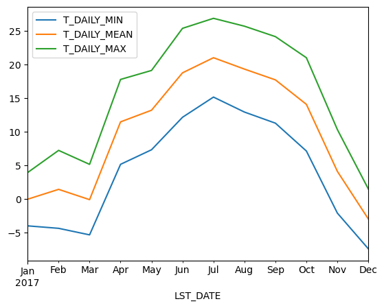

```python
df_mm = df.resample('MS').mean()
df_mm[['T_DAILY_MIN','T_DAILY_MEAN','T_DAILY_MAX']].plot()
```

# Pandas: Groupby

`groupby` is an amazingly powerful function in pandas. But it is also complicated to use and understand. The point of this lesson is to make you feel confident in using `groupby` and its cousins, `resample` and `rolling`.

These notes are loosely based on the [Pandas GroupBy Documentation](http://pandas.pydata.org/pandas-docs/stable/groupby.html).

The "split/apply/combine" concept was first introduced in a paper by Hadley Wickham: https://www.jstatsoft.org/article/view/v040i01.

## Credit:

this comes from Abernathys open book, which we will be looking at a lot! https://earth-env-data-science.github.io/lectures/core_python/python_fundamentals.html

Imports:

```python
import numpy as np
from matplotlib import pyplot as plt
import pandas as pd
%matplotlib inline
```

First we read in some Earthquake data.

In this case, we are loading **straight from a webpage** -- its like a relative path, but pointed at a remote file

```python
# url = 'https://www.ldeo.columbia.edu/~rpa/usgs_earthquakes_2014.csv'
# url = 'https://github.com/rucool/RUCOOL_Software_Bootcamp/blob/main/2024_earthquakes_all_25.csv'
# url = './data/2024_earthquakes_all_25.csv'
url = 'https://raw.githubusercontent.com/rucool/RUCOOL_Software_Bootcamp/refs/heads/main/2024_earthquakes_all_25.csv'

df = pd.read_csv(url,parse_dates=['time'], index_col='id')

# don't worry about this step:
df['country'] = df.place.str.split(', ').str[-1]
df_small = df[df.mag<4] # File is different than original example, is normally 4. Need to add in a different dataset.
df = df[df.mag>4]
df.head()
```

| id | time | latitude | longitude | depth | mag | magType | nst | gap | dmin | rms | ... | place | type | horizontalError | depthError | magError | magNst | status | locationSource | magSource | country |
| --- | --- | --- | --- | --- | --- | --- | --- | --- | --- | --- | --- | --- | --- | --- | --- | --- | --- | --- | --- | --- | --- |
| us6000pgkh | 2024-12-30 23:56:29.977000+00:00 | -5.7603 | 148.9729 | 127.013 | 4.6 | mb | 47.0 | 109.0 | 3.367 | 0.44 | ... | 80 km NW of Kandrian, Papua New Guinea | earthquake | 9.68 | 7.431 | 0.089 | 38.0 | reviewed | us | us | Papua New Guinea |
| us6000pgkd | 2024-12-30 23:40:33.868000+00:00 | -17.6089 | -178.3937 | 573.817 | 4.6 | mb | 69.0 | 110.0 | 2.417 | 0.60 | ... | 247 km ENE of Levuka, Fiji | earthquake | 14.54 | 8.251 | 0.087 | 39.0 | reviewed | us | us | Fiji |
| us6000pj76 | 2024-12-30 23:36:27.672000+00:00 | 9.5417 | 40.0566 | 10.000 | 4.3 | mb | 17.0 | 131.0 | 1.504 | 0.40 | ... | 46 km SE of Debre Sīna, Ethiopia | earthquake | 9.15 | 1.825 | 0.148 | 13.0 | reviewed | us | us | Ethiopia |
| us6000pgkb | 2024-12-30 23:30:59.974000+00:00 | 9.1189 | 39.9276 | 10.000 | 4.7 | mb | 66.0 | 185.0 | 1.253 | 0.59 | ... | 24 km N of Metahāra, Ethiopia | earthquake | 10.00 | 1.969 | 0.075 | 53.0 | reviewed | us | us | Ethiopia |
| us6000pj77 | 2024-12-30 23:16:09.495000+00:00 | -19.2777 | -175.9927 | 10.000 | 4.6 | mb | 17.0 | 168.0 | 5.220 | 0.65 | ... | 181 km WNW of Pangai, Tonga | earthquake | 15.91 | 1.962 | 0.136 | 16.0 | reviewed | us | us | Tonga |

5 rows × 22 columns

## An Example

This is an example of a "one-liner" that you can accomplish with groupby.

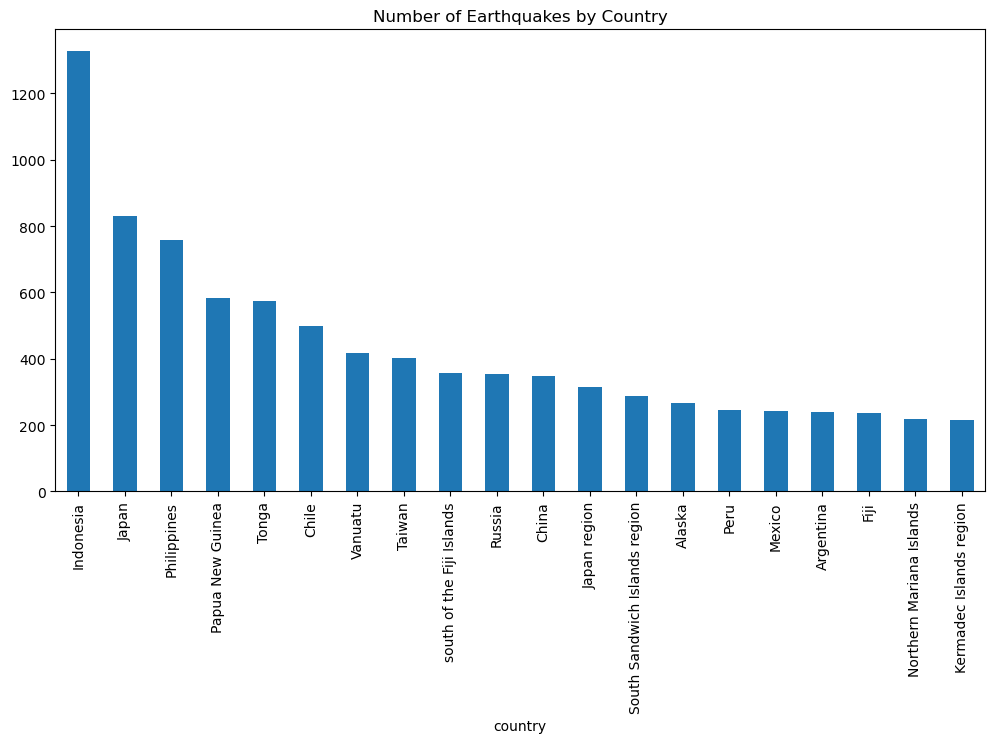

```python
df.groupby('country').mag.count().nlargest(20).plot(kind='bar', figsize=(12,6), title='Number of Earthquakes by Country')
```

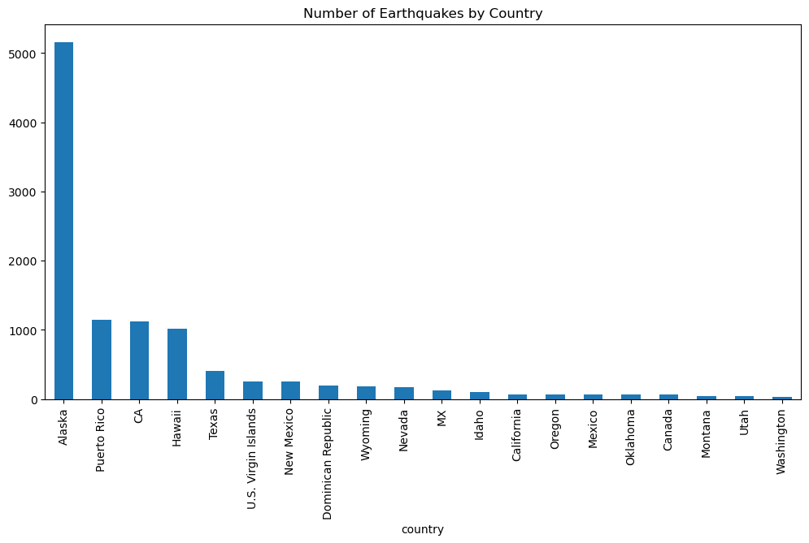

```python
df_small.groupby('country').mag.count().nlargest(20).plot(kind='bar', figsize=(12,6), title='Number of Earthquakes by Country')
```

## What Happened?

Let's break apart this operation a bit. The workflow with `groubpy` can be divided into three general steps:

1. **Split**: Partition the data into different groups based on some criterion.
2. **Apply**: Do some caclulation within each group. Different types of "apply" steps might be
3. *Aggregation*: Get the mean or max within the group.
4. *Transformation*: Normalize all the values within a group
5. *Filtration*: Eliminate some groups based on a criterion.
6. **Combine**: Put the results back together into a single object.

[figure not shown]

### The `groupby` method

Both `Series` and `DataFrame` objects have a groupby method. It accepts a variety of arguments, but the simplest way to think about it is that you pass another series, whose unique values are used to split the original object into different groups.

via https://medium.com/analytics-vidhya/split-apply-combine-strategy-for-data-mining-4fd6e2a0cc99

```python
df.groupby('country')
```

```
<pandas.core.groupby.generic.DataFrameGroupBy object at 0x185d9cfc0>
```

```python
df.groupby(df.country)
```

```
<pandas.core.groupby.generic.DataFrameGroupBy object at 0x1865dd250>
```

### The `GroubBy` object

When we call, `groupby` we get back a `GroupBy` object, which is like a dictionary, where the keys are each group, and the values are the data that correspond to that group

```python
gb = df.groupby('country')
gb
```

```
<pandas.core.groupby.generic.DataFrameGroupBy object at 0x186451480>
```

The length tells us how many groups were found:

```python
len(gb)
```

```
242
```

All of the groups are available as a dictionary via the `.groups` attribute:

```python
groups = gb.groups
len(groups)
```

```
242
```

```python
groups.keys()
```

```
dict_keys(['Afghanistan', 'Alaska', 'Albania', 'Algeria', 'American Samoa', 'Angola', 'Anguilla', 'Antigua and Barbuda', 'Arctic Ocean', 'Argentina', 'Armenia', 'Ascension Island region', 'Australia', 'Azerbaijan', 'Azores Islands region', 'Balleny Islands region', 'Banda Sea', 'Bangladesh', 'Barbad…
```

And you can get a specific group by key.

```python
gb.get_group('Japan').head()
```

| id | time | latitude | longitude | depth | mag | magType | nst | gap | dmin | rms | ... | place | type | horizontalError | depthError | magError | magNst | status | locationSource | magSource | country |
| --- | --- | --- | --- | --- | --- | --- | --- | --- | --- | --- | --- | --- | --- | --- | --- | --- | --- | --- | --- | --- | --- |
| us6000pggp | 2024-12-30 09:20:53.874000+00:00 | 28.0377 | 128.0619 | 10.00 | 4.4 | mb | 31.0 | 87.0 | 1.212 | 0.78 | ... | 86 km WNW of Amagi, Japan | earthquake | 5.28 | 1.614 | 0.123 | 20.0 | reviewed | us | us | Japan |
| us6000pgem | 2024-12-30 05:14:36.140000+00:00 | 23.4756 | 123.4996 | 10.00 | 4.3 | mb | 33.0 | 132.0 | 1.083 | 0.68 | ... | 117 km SW of Ishigaki, Japan | earthquake | 4.17 | 1.921 | 0.142 | 14.0 | reviewed | us | us | Japan |
| us6000pj6j | 2024-12-30 05:11:38.419000+00:00 | 27.9479 | 127.8182 | 10.00 | 4.5 | mb | 42.0 | 79.0 | 1.179 | 0.57 | ... | 100 km NW of China, Japan | earthquake | 7.01 | 1.902 | 0.110 | 24.0 | reviewed | us | us | Japan |
| us6000pgag | 2024-12-29 13:18:15.288000+00:00 | 23.4023 | 126.3383 | 10.00 | 4.4 | mb | 43.0 | 113.0 | 2.157 | 0.86 | ... | 185 km SE of Miyakojima, Japan | earthquake | 10.87 | 1.914 | 0.098 | 30.0 | reviewed | us | us | Japan |
| us6000pg8l | 2024-12-29 05:19:54.131000+00:00 | 41.5630 | 141.2192 | 108.43 | 4.4 | mb | 55.0 | 116.0 | 0.782 | 0.57 | ... | 26 km E of Ōma, Japan | earthquake | 9.66 | 9.432 | 0.075 | 51.0 | reviewed | us | us | Japan |

5 rows × 22 columns

## Aggregation

Now that we know how to create a `GroupBy` object, let's learn how to do aggregation on it.

One way us to use the `.aggregate` method, which accepts another function as its argument. The result is automatically combined into a new dataframe with the group key as the index.

```python
gb.aggregate('max').head()
```

| country | time | latitude | longitude | depth | mag | magType | nst | gap | dmin | rms | ... | updated | place | type | horizontalError | depthError | magError | magNst | status | locationSource | magSource |
| --- | --- | --- | --- | --- | --- | --- | --- | --- | --- | --- | --- | --- | --- | --- | --- | --- | --- | --- | --- | --- | --- |
| Afghanistan | 2024-12-29 17:35:41.050000+00:00 | 37.5217 | 72.2750 | 234.928 | 6.4 | mww | 199.0 | 268.0 | 4.432 | 1.29 | ... | 2025-03-08T22:39:12.040Z | 8 km WNW of Ashkāsham, Afghanistan | earthquake | 11.61 | 19.367 | 0.233 | 280.0 | reviewed | us | us |
| Alaska | 2024-12-28 03:26:26.194000+00:00 | 67.8730 | 179.9298 | 250.064 | 6.3 | mww | 326.0 | 288.0 | 2.479 | 1.34 | ... | 2025-08-08T00:22:07.212Z | Rat Islands, Aleutian Islands, Alaska | earthquake | 17.94 | 15.839 | 0.261 | 635.0 | reviewed | us | us |
| Albania | 2024-09-13 05:33:58.567000+00:00 | 41.6324 | 20.6652 | 28.604 | 4.5 | mwr | 106.0 | 97.0 | 1.405 | 1.08 | ... | 2024-11-21T22:58:54.040Z | 7 km NE of Lushnjë, Albania | earthquake | 5.56 | 7.138 | 0.308 | 45.0 | reviewed | us | us |
| Algeria | 2024-12-16 00:09:46.958000+00:00 | 36.9912 | 4.6777 | 10.000 | 5.0 | mb | 81.0 | 83.0 | 3.838 | 0.95 | ... | 2025-02-27T17:30:50.040Z | 51 km SSE of M’sila, Algeria | earthquake | 8.72 | 4.574 | 0.127 | 78.0 | reviewed | us | us |
| American Samoa | 2024-07-13 08:02:00.985000+00:00 | -15.4305 | -171.6794 | 10.000 | 4.4 | mb | 11.0 | 122.0 | 1.516 | 0.37 | ... | 2024-09-20T16:00:51.040Z | 153 km SW of Vailoatai, American Samoa | earthquake | 6.86 | 1.913 | 0.219 | 6.0 | reviewed | us | us |

5 rows × 21 columns

By default, the operation is applied to every column. That's usually not what we want. We can use both `.` or `[]` syntax to select a specific column to operate on. Then we get back a series.

```python
gb.mag.aggregate('max').head()
```

```
country
Afghanistan       6.4
Alaska            6.3
Albania           4.5
Algeria           5.0
American Samoa    4.4
Name: mag, dtype: float64
```

```python
gb.mag.aggregate('max').nlargest(10)
```

```
country
Japan Earthquake         7.5
Chile                    7.4
Taiwan                   7.4
Vanuatu                  7.3
Peru                     7.2
Philippines              7.1
California Earthquake    7.0
China                    7.0
Russia                   7.0
Papua New Guinea         6.9
Name: mag, dtype: float64
```

There are shortcuts for common aggregation functions:

```python
gb.mag.max().nlargest(10)
```

```
country
Japan Earthquake         7.5
Chile                    7.4
Taiwan                   7.4
Vanuatu                  7.3
Peru                     7.2
Philippines              7.1
California Earthquake    7.0
China                    7.0
Russia                   7.0
Papua New Guinea         6.9
Name: mag, dtype: float64
```

```python
df.groupby('country').mag.mean().nlargest(10)
```

```
country
Japan Earthquake               7.300
California Earthquake          7.000
Nevada Earthquake              5.700
Brazil                         5.575
Madagascar                     5.300
Mauritius - Reunion region     5.300
French Southern Territories    5.200
New Zealand region             5.200
South Pacific Ocean            5.200
Barbados                       5.100
Name: mag, dtype: float64
```

```python
df.groupby('country').mag.std().nlargest(10)
```

```
country
Brazil                                1.172959
Sea of Okhotsk                        0.953939
Cuba                                  0.922617
Macquarie Island region               0.697681
Mauritius - Reunion region            0.681909
east of the South Sandwich Islands    0.680074
Bosnia and Herzegovina                0.623832
Vanuatu region                        0.564337
Oregon                                0.546155
south of Africa                       0.525015
Name: mag, dtype: float64
```

We can also apply multiple functions at once:

```python
gb.mag.aggregate(['min', 'max', 'mean']).head()
```

| country | min | max | mean |
| --- | --- | --- | --- |
| Afghanistan | 4.1 | 6.4 | 4.337838 |
| Alaska | 4.1 | 6.3 | 4.560150 |
| Albania | 4.1 | 4.5 | 4.283333 |
| Algeria | 4.3 | 5.0 | 4.600000 |
| American Samoa | 4.4 | 4.4 | 4.400000 |

## Transformation

The key difference between aggregation and transformation is that aggregation returns a *smaller* object than the original, indexed by the group keys, while *transformation* returns an object with the same index (and same size) as the original object. Groupby + transformation is used when applying an operation that requires information about the whole group.

In this example, we standardize the earthquakes in each country so that the distribution has zero mean and unit variance. We do this by first defining a function called `standardize` and then passing it to the `transform` method.

I admit that I don't know why you would want to do this. `transform` makes more sense to me in the context of time grouping operation. See below for another example.

```python
def standardize(x):
    return (x - x.mean()) / x.std()

mag_standardize_by_country = gb.mag.transform(standardize)
mag_standardize_by_country.head()
```

```
id
us6000pgkh    0.090467
us6000pgkd    0.678202
us6000pj76   -0.754017
us6000pgkb    1.025246
us6000pj77    0.023195
Name: mag, dtype: float64
```

## Time Grouping

We already saw how pandas has a strong built-in understanding of time. This capability is even more powerful in the context of `groupby`. With datasets indexed by a pandas `DateTimeIndex`, we can easily group and resample the data using common time units.

To get started, let's load the timeseries data we already explored in past lessons.

```python
import urllib

header_url = 'ftp://ftp.ncdc.noaa.gov/pub/data/uscrn/products/daily01/HEADERS.txt'

with urllib.request.urlopen(header_url) as response:
    data = response.read().decode('utf-8')
lines = data.split('\n')
headers = lines[1].split(' ')
headers
```

```
['WBANNO',
 'LST_DATE',
 'CRX_VN',
 'LONGITUDE',
 'LATITUDE',
 'T_DAILY_MAX',
 'T_DAILY_MIN',
 'T_DAILY_MEAN',
 'T_DAILY_AVG',
 'P_DAILY_CALC',
 'SOLARAD_DAILY',
 'SUR_TEMP_DAILY_TYPE',
 'SUR_TEMP_DAILY_MAX',
 'SUR_TEMP_DAILY_MIN',
 'SUR_TEMP_DAILY_AVG',
 'RH_DAILY_MAX',
 'RH_DAILY_MIN',
 'RH_DAILY_AVG',
 'SOIL_MOISTURE_5_DAILY',
 'SOIL_MOISTURE_10_DAILY',
 'SOIL_MOISTURE_20_DAILY',
 'SOIL_MOISTURE_50_DAILY',
 'SOIL_MOISTURE_100_DAILY',
 'SOIL_TEMP_5_DAILY',
 'SOIL_TEMP_10_DAILY',
 'SOIL_TEMP_20_DAILY',
 'SOIL_TEMP_50_DAILY',
 'SOIL_TEMP_100_DAILY',
 '']
```

```python
ftp_base = 'ftp://ftp.ncdc.noaa.gov/pub/data/uscrn/products/daily01/'
dframes = []
for year in range(2017, 2020):
    data_url = f'{year}/CRND0103-{year}-NY_Millbrook_3_W.txt'
    df = pd.read_csv(ftp_base + data_url, parse_dates=[1],
                    names = headers, header = None, sep=r'\s+',
                    na_values = [-9999.0, -99.0])
    dframes.append(df)

df = pd.concat(dframes)
df = df.set_index('LST_DATE')
```

```python
print(df.info()) # check the data-types, might mess up in some groupby commands
df = df.drop('SUR_TEMP_DAILY_TYPE', axis = 1)
print(df.info())
```

```
<class 'pandas.core.frame.DataFrame'>
DatetimeIndex: 1095 entries, 2017-01-01 to 2019-12-31
Data columns (total 28 columns):
 #   Column                   Non-Null Count  Dtype
---  ------                   --------------  -----
 0   WBANNO                   1095 non-null   int64
 1   CRX_VN                   1095 non-null   float64
 2   LONGITUDE                1095 non-null   float64
 3   LATITUDE                 1095 non-null   float64
 4   T_DAILY_MAX              1085 non-null   float64
 5   T_DAILY_MIN              1085 non-null   float64
 6   T_DAILY_MEAN             1085 non-null   float64
 7   T_DAILY_AVG              1085 non-null   float64
 8   P_DAILY_CALC             1086 non-null   float64
 9   SOLARAD_DAILY            1085 non-null   float64
```

[output cut: 56 more lines]

```python
df.head()
```

| LST_DATE | WBANNO | CRX_VN | LONGITUDE | LATITUDE | T_DAILY_MAX | T_DAILY_MIN | T_DAILY_MEAN | T_DAILY_AVG | P_DAILY_CALC | SOLARAD_DAILY | ... | SOIL_MOISTURE_10_DAILY | SOIL_MOISTURE_20_DAILY | SOIL_MOISTURE_50_DAILY | SOIL_MOISTURE_100_DAILY | SOIL_TEMP_5_DAILY | SOIL_TEMP_10_DAILY | SOIL_TEMP_20_DAILY | SOIL_TEMP_50_DAILY | SOIL_TEMP_100_DAILY |  |
| --- | --- | --- | --- | --- | --- | --- | --- | --- | --- | --- | --- | --- | --- | --- | --- | --- | --- | --- | --- | --- | --- |
| 2017-01-01 | 64756 | 2.422 | -73.74 | 41.79 | 6.6 | -5.4 | 0.6 | 2.2 | 0.0 | 8.68 | ... | NaN | 0.207 | 0.152 | 0.175 | -0.1 | 0.0 | 0.6 | 1.5 | 3.4 | NaN |
| 2017-01-02 | 64756 | 2.422 | -73.74 | 41.79 | 4.0 | -6.8 | -1.4 | -1.2 | 0.0 | 2.08 | ... | NaN | 0.205 | 0.151 | 0.173 | -0.2 | 0.0 | 0.6 | 1.5 | 3.3 | NaN |
| 2017-01-03 | 64756 | 2.422 | -73.74 | 41.79 | 4.9 | 0.7 | 2.8 | 2.7 | 13.1 | 0.68 | ... | NaN | 0.205 | 0.150 | 0.173 | -0.1 | 0.0 | 0.5 | 1.5 | 3.3 | NaN |
| 2017-01-04 | 64756 | 2.422 | -73.74 | 41.79 | 8.7 | -1.6 | 3.6 | 3.5 | 1.3 | 2.85 | ... | NaN | 0.215 | 0.153 | 0.174 | -0.1 | 0.0 | 0.5 | 1.5 | 3.2 | NaN |
| 2017-01-05 | 64756 | 2.422 | -73.74 | 41.79 | -0.5 | -4.6 | -2.5 | -2.8 | 0.0 | 4.90 | ... | NaN | 0.215 | 0.154 | 0.177 | -0.1 | 0.0 | 0.5 | 1.4 | 3.1 | NaN |

5 rows × 27 columns

This timeseries has daily resolution, and the daily plots are somewhat noisy.

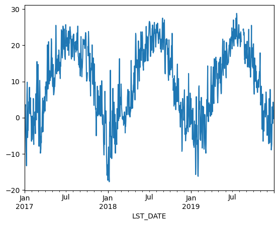

```python
df.T_DAILY_MEAN.plot()
```

A common way to analyze such data in climate science is to create a "climatology," which contains the average values in each month or day of the year. We can do this easily with groupby. Recall that `df.index` is a pandas `DateTimeIndex` object.

```python
monthly_climatology = df.groupby(df.index.month).mean(numeric_only = True)
monthly_climatology
```

| LST_DATE | WBANNO | CRX_VN | LONGITUDE | LATITUDE | T_DAILY_MAX | T_DAILY_MIN | T_DAILY_MEAN | T_DAILY_AVG | P_DAILY_CALC | SOLARAD_DAILY | ... | SOIL_MOISTURE_10_DAILY | SOIL_MOISTURE_20_DAILY | SOIL_MOISTURE_50_DAILY | SOIL_MOISTURE_100_DAILY | SOIL_TEMP_5_DAILY | SOIL_TEMP_10_DAILY | SOIL_TEMP_20_DAILY | SOIL_TEMP_50_DAILY | SOIL_TEMP_100_DAILY |  |
| --- | --- | --- | --- | --- | --- | --- | --- | --- | --- | --- | --- | --- | --- | --- | --- | --- | --- | --- | --- | --- | --- |
| 1 | 64756.0 | 2.555333 | -73.74 | 41.79 | 2.064516 | -7.703226 | -2.821505 | -2.539785 | 3.274194 | 5.343011 | ... | 0.275455 | 0.226514 | 0.169140 | 0.179000 | 0.164516 | 0.229032 | 0.653763 | 1.568817 | 2.938710 | NaN |
| 2 | 64756.0 | 2.555333 | -73.74 | 41.79 | 5.582143 | -5.095238 | 0.246429 | 0.496429 | 3.292857 | 8.661786 | ... | 0.254222 | 0.217609 | 0.173524 | 0.180452 | 0.775000 | 0.729762 | 0.848810 | 1.253571 | 2.073810 | NaN |
| 3 | 64756.0 | 2.555333 | -73.74 | 41.79 | 6.093548 | -4.308602 | 0.882796 | 1.151613 | 3.040860 | 12.818602 | ... | 0.247028 | 0.220911 | 0.173065 | 0.178935 | 1.951613 | 1.897849 | 1.962366 | 2.213978 | 2.733333 | NaN |
| 4 | 64756.0 | 2.555333 | -73.74 | 41.79 | 15.212222 | 2.637778 | 8.921111 | 9.103333 | 3.116667 | 14.033333 | ... | 0.229900 | 0.229689 | 0.171400 | 0.177511 | 9.512222 | 9.217778 | 8.538889 | 7.556667 | 6.448889 | NaN |
| 5 | 64756.0 | 2.555333 | -73.74 | 41.79 | 20.736559 | 8.646237 | 14.684946 | 14.890323 | 3.392473 | 16.514301 | ... | 0.212452 | 0.221366 | 0.163968 | 0.174129 | 16.801075 | 16.561290 | 15.616129 | 14.230108 | 12.527957 | NaN |
| 6 | 64756.0 | 2.555333 | -73.74 | 41.79 | 25.176667 | 11.970000 | 18.572222 | 18.910000 | 3.116667 | 20.695333 | ... | 0.149900 | 0.166044 | 0.139178 | 0.163800 | 21.878889 | 21.677778 | 20.660000 | 19.120000 | 17.257778 | NaN |
| 7 | 64756.0 | 2.555333 | -73.74 | 41.79 | 28.738710 | 15.726882 | 22.233333 | 22.161290 | 4.025806 | 21.516667 | ... | 0.104409 | 0.105011 | 0.118473 | 0.142242 | 25.419355 | 25.329032 | 24.296739 | 22.791398 | 21.054348 | NaN |
| 8 | 64756.0 | 1.930495 | -73.74 | 41.79 | 26.951163 | 14.865116 | 20.909302 | 20.762791 | 4.647674 | 17.980581 | ... | 0.149570 | 0.134826 | 0.133488 | 0.141631 | 24.244186 | 24.319767 | 23.738372 | 23.005814 | 22.069767 | NaN |
| 9 | 64756.0 | 2.555333 | -73.74 | 41.79 | 23.584270 | 11.620225 | 17.597753 | 17.351685 | 3.795506 | 13.392697 | ... | 0.144854 | 0.131742 | 0.128730 | 0.145919 | 20.379775 | 20.478652 | 20.294382 | 20.258427 | 20.140449 | NaN |
| 10 | 64756.0 | 2.615548 | -73.74 | 41.79 | 17.941758 | 6.195604 | 12.068132 | 12.105495 | 4.103261 | 8.731319 | ... | 0.190637 | 0.170187 | 0.141385 | 0.144099 | 14.970330 | 15.108791 | 15.331868 | 16.028571 | 16.756044 | NaN |
| 11 | 64756.0 | 2.622000 | -73.74 | 41.79 | 8.260000 | -2.223333 | 3.012222 | 3.154444 | 3.783333 | 6.064778 | ... | 0.243633 | 0.241344 | 0.177533 | 0.173689 | 6.404444 | 6.615556 | 7.347778 | 8.844444 | 10.594444 | NaN |
| 12 | 64756.0 | 2.622000 | -73.74 | 41.79 | 3.316129 | -5.867742 | -1.282796 | -0.983871 | 3.348387 | 4.411613 | ... | 0.262038 | 0.235247 | 0.177398 | 0.174978 | 1.861290 | 1.976344 | 2.522581 | 3.761290 | 5.382796 | NaN |

12 rows × 27 columns

Each row in this new dataframe respresents the average values for the months (1=January, 2=February, etc.)

We can apply more customized aggregations, as with any groupby operation. Below we keep the mean of the mean, max of the max, and min of the min for the temperature measurements.

```python
monthly_T_climatology = df.groupby(df.index.month).aggregate({'T_DAILY_MEAN':'mean','T_DAILY_MAX':'max','T_DAILY_MIN':'min'})
monthly_climatology.head()
```

| LST_DATE | WBANNO | CRX_VN | LONGITUDE | LATITUDE | T_DAILY_MAX | T_DAILY_MIN | T_DAILY_MEAN | T_DAILY_AVG | P_DAILY_CALC | SOLARAD_DAILY | ... | SOIL_MOISTURE_10_DAILY | SOIL_MOISTURE_20_DAILY | SOIL_MOISTURE_50_DAILY | SOIL_MOISTURE_100_DAILY | SOIL_TEMP_5_DAILY | SOIL_TEMP_10_DAILY | SOIL_TEMP_20_DAILY | SOIL_TEMP_50_DAILY | SOIL_TEMP_100_DAILY |  |
| --- | --- | --- | --- | --- | --- | --- | --- | --- | --- | --- | --- | --- | --- | --- | --- | --- | --- | --- | --- | --- | --- |
| 1 | 64756.0 | 2.555333 | -73.74 | 41.79 | 2.064516 | -7.703226 | -2.821505 | -2.539785 | 3.274194 | 5.343011 | ... | 0.275455 | 0.226514 | 0.169140 | 0.179000 | 0.164516 | 0.229032 | 0.653763 | 1.568817 | 2.938710 | NaN |
| 2 | 64756.0 | 2.555333 | -73.74 | 41.79 | 5.582143 | -5.095238 | 0.246429 | 0.496429 | 3.292857 | 8.661786 | ... | 0.254222 | 0.217609 | 0.173524 | 0.180452 | 0.775000 | 0.729762 | 0.848810 | 1.253571 | 2.073810 | NaN |
| 3 | 64756.0 | 2.555333 | -73.74 | 41.79 | 6.093548 | -4.308602 | 0.882796 | 1.151613 | 3.040860 | 12.818602 | ... | 0.247028 | 0.220911 | 0.173065 | 0.178935 | 1.951613 | 1.897849 | 1.962366 | 2.213978 | 2.733333 | NaN |
| 4 | 64756.0 | 2.555333 | -73.74 | 41.79 | 15.212222 | 2.637778 | 8.921111 | 9.103333 | 3.116667 | 14.033333 | ... | 0.229900 | 0.229689 | 0.171400 | 0.177511 | 9.512222 | 9.217778 | 8.538889 | 7.556667 | 6.448889 | NaN |
| 5 | 64756.0 | 2.555333 | -73.74 | 41.79 | 20.736559 | 8.646237 | 14.684946 | 14.890323 | 3.392473 | 16.514301 | ... | 0.212452 | 0.221366 | 0.163968 | 0.174129 | 16.801075 | 16.561290 | 15.616129 | 14.230108 | 12.527957 | NaN |

5 rows × 27 columns

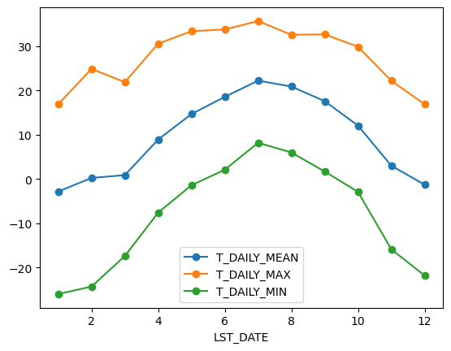

```python
monthly_T_climatology.plot(marker='o')
```

If we want to do it on a finer scale, we can group by day of year.

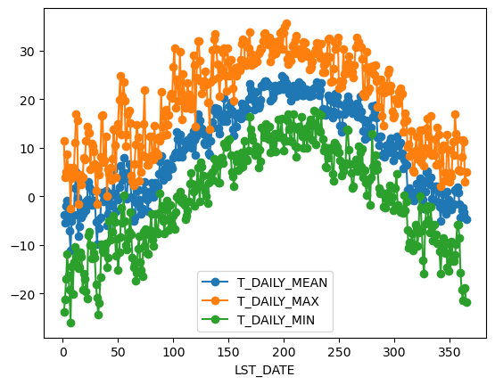

```python
daily_T_climatology = df.groupby(df.index.dayofyear).aggregate({'T_DAILY_MEAN':'mean','T_DAILY_MAX':'max','T_DAILY_MIN':'min'})
daily_T_climatology.plot(marker='o')
```

### Calculating anomalies

A common mode of analysis in climate science is to remove the climatology from a signal to focus only on the "anomaly" values. This can be accomplished with transformation.

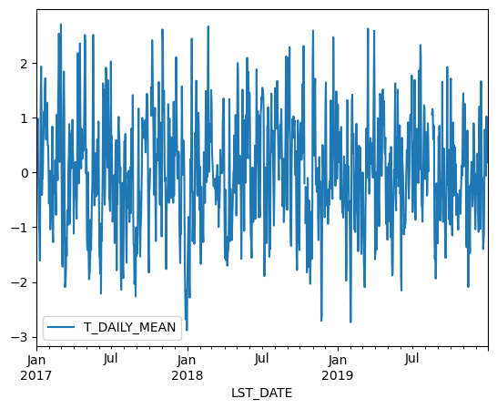

```python
def standardize(x):
    return(x-x.mean())/x.std()

anomaly = df.groupby(df.index.month).transform(standardize)
anomaly.plot(y='T_DAILY_MEAN')
```

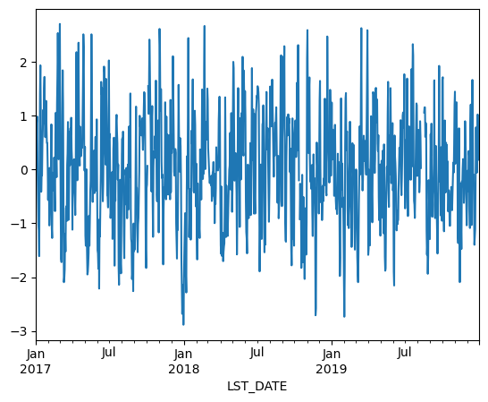

```python
anomaly = df.groupby(df.index.month).T_DAILY_MEAN.transform(standardize)
anomaly.plot()
```

# Xarray

In this lesson we are going to learn about the `Xarray` library - one of the most useful libraries available to us as earth/ocean/atmospheric researchers.

### credit

This lesson is from the Geohackweek tutorial on Xarray (https://geohackweek.github.io/nDarrays/), and Abernathy's book: (https://earth-env-data-science.github.io/lectures/xarray/xarray_intro.html).

### Think of Xarray as a bit like numpy, except that it has a better 'understanding' of the dimensions of your data.

## Multidimensional Arrays

(not as scary as they sound)

### Like a table in Excel but with more than two dimensions

Let's start by drawing some 2D arrays (familiar spreadsheets) on the board. List a bunch of types of data that might fit in that format.

Now extend this idea: what are common examples of 3D arrays? What type of ocean/earth/atmos data might fit this format? Can we see how they are easily related to 2D arrays?

```python
# list some types of N-d arrays that you migh work with

# A movie is a time series of 2D images, so is a 3D dataset

# A series of satellite images is a bit like a movie too, so is also 3D

# Output from numerical simulation might be 3D or 4D even
```

# What is Xarray?

Xarray is a python library that brings the convienient features of Pandas to higher dimensions. It was initally developed by people at the Climate Corporation for dealing with climate data. It turns out it's very useful in much of our work.

Like Pandas, Xarray let's us do operations on named dimensions. It keeps a lot of the 'metadata' associted with the actually data that makes plotting, calculating, and grouping much easier.

It also is a great way to load data formats that we will see a lot in our work, in particular NetCDFs (more on this later).

features:

the `DataArray` is Xarray’s standard data type: a labeled, multi-dimensional array

the `DataArray` has these key properties:

- `data`: N-dimensional array (NumPy or dask) holding the array’s values, i.e. your actual data,
- `dims`: dimension names for each axis, just the names, like 'latitude' or 'longitude' or 'time'
- `coords`: dictionary-like container of arrays that label each point, i.e. the actual values of each axis like time or latitue or something
- `attrs`: ordered dictionary holding metadata, or 'attributes', like the data units, person who collected, any of that stuff

The second main data structure is the `Dataset` - which you can think of as a group of `DataArray`, like perhaps a grid that has a temperature `DataArray`, a salinity `DataArray`, and an oxygen `DataArray` that are all from the same instument or model and belong together. These can be housed within one `Dataset`. We will show this later

# When to use Xarray?

- if your data are multidimensional, like lat, lon, x, y, z, time ...
- if your data are on a regular grid (output from a model)
- if your data are contained in a `.nc` netcdf file.

[figure not shown]

# What can Xarray do for *me*?

Think about how you would want to build a data structure. Let's go through on the board all the things that should go along with your data. For concretness let's think about the temperature at all depths and points in the mid-Atlantic Bight, from a model say. What do we need to know? We can name all those vectors, but wouldn't it be easier if they all lived with the data itself??

# Build a simple DataArray

That is maybe a lot of complex info. Let's start from the basic basics and build up our own `DataArray` using Xarray to see how all it's parts work

We will start with some fake data, just a sequence of numbers. Make up something about what they are.

We need to download xarray using `conda` like we have before:

### installing `xarray` with (Ana)conda (if you don't have it installed already or there was a problem)

to get `xarray` (you should only need to do this once):

1. go to the little `+` on the left to open a `launcher` window.
2. click the 'terminal' tile to open a terminal
3. type `conda env list` and hit enter. Make sure that there is a `*` next to the line that says swbc
4. if that's right type `conda install xarray dask netCDF4 bottleneck pandas`
5. when it asks `proceed ([y]/n)?` type `y` and hit enter

Of course, to start we need to import xarray. To save typing we usualy ask python to call xarray 'xr'

```python
# import xarray and matplotlib
import xarray as xr
import matplotlib.pyplot as plt
%matplotlib inline
```

Now let's use the `xr.DataArray()` function to make our fake dataarray

```python
da = xr.DataArray([ 1, 2, 5, 7, 10])

da
```

```
<xarray.DataArray (dim_0: 5)> Size: 40B
array([ 1,  2,  5,  7, 10])
Dimensions without coordinates: dim_0
```

Ok, that is just some data, a few numbers. So far this isn't anything more special than a numpy array. But it'll get better if we can give it some dimensions and coordinates that give the data context. Maybe those are the number of birds we counted at 10 minute intervals while we were staring out the window in class.

Let's add the dimention `time` to the DataArray:

```python
da = xr.DataArray( [ 1, 2, 5, 7, 10], dims=["time"])

da
```

```
<xarray.DataArray (time: 5)> Size: 40B
array([ 1,  2,  5,  7, 10])
Dimensions without coordinates: time
```

Ok, now we know that the data correspond to times, that's good. It's giving us a more complete understanding of the context of the data. But what times?

We've named the dimension, but now let's give it some coordinates, in otherwords let's specify the exact times when we measured those birds.

In order to connect the dimension to an actual set of time points (i.e. coordinates) we need to recall a Python data type we talked about a while ago.

## Quick Aside: Dictionaries - remember that python data type?

Quick summary: A Dictionary is a lot like a list, but it has a label for each element in the list. Namely a Dictionary is made up of key : values pairs. You can think of it literally like a dictonary: you'd look something by it's name (key) and there would be other information in there (the values). We define a ditionary uscing curly brackets: `dict = {}` and we separate keys from their values with a colon `:`

```
d = {
    <key>: <value>,
    <key>: <value>,
      .
      .
      .
    <key>: <value>
}
```

For example we can make a dictionary where the key is a city, and the value is that city's baseball team:

```
MLB_team = {
     'Colorado' : 'Rockies',
     'Boston'   : 'Red Sox',
     'Minnesota': 'Twins',
     'Milwaukee': 'Brewers',
     'Seattle'  : 'Mariners'
 }
```

Dictionaries aren't too complicated, they are just another way of storing data. We will use them a lot with xarrays.

One use case we can talk about now, we have decided the dimension of our DataArray is time, and we can use a dictionary to associate that key (time) with values ( t1, t2, t3, etc).

When we specify the coordinates, we need to tell xarray that we are refering to the `time` dimention, and then tell it what times we want to include:

```python
da = xr.DataArray( [ 1, 2, 5, 7, 3],
                  dims=['time'],
                 coords = {'time': range(5)})

# da['time'] = [1,2,3,4,5]
da
```

```
<xarray.DataArray (time: 5)> Size: 40B
array([1, 2, 5, 7, 3])
Coordinates:
  * time     (time) int64 40B 0 1 2 3 4
```

```python
# da.attrs = {'data':'bird observations','time':'minutes'}
da.attrs = {'units':'bird observations','time':'minutes'}
da
```

```
<xarray.DataArray (time: 5)> Size: 40B
array([1, 2, 5, 7, 3])
Coordinates:
  * time     (time) int64 40B 0 1 2 3 4
Attributes:
    units:    bird observations
    time:     minutes
```

Now we have something that pretty much fully describes our experiment (almost, what might we be missing? what about attributue? can you think of some examaples?)

From here Xarray has all sorts of built in functions that allow you to interact with your data quickly. Because the DataArray has data, dimentions, and coordinates, Xarray can internally understand a lot about the data.

One thing we can do is just ask xarray to make a simple plot. This takes almost no code:

```
<xarray.plot.accessor.DataArrayPlotAccessor at 0x18828f400>
```

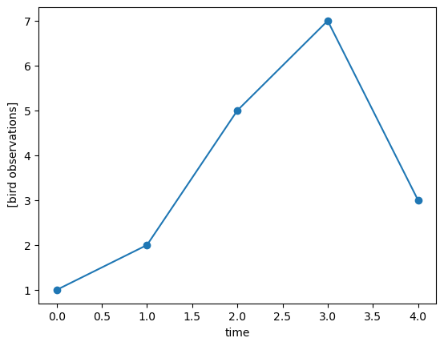

```python
# da.plot()
da.plot(marker='o')
da.plot
# or do shifttab after da.plot to see help
```

The end...

# Breakout / exercise 01

# Build a mulidimentional DataArray

We made up some data in the simple example. Also, did you notice it's just one dimentional? Let's go through the excercise by building some a multidimentional dataset.

This is in the next notebook

## Exercise 01 - Make your own DataArray

For this exercise we are going to steal a fuction from the library `pandas`, even though we didn't learn about it yet. The function is called `date_range` and it creates an array of dates. Look at the code below, can you figure out what it does?

**Task**: Make an xarray dataarray of fake data. Make a dim for time, for the coordinates use `two_years` and for the data use `fake_data` defined as:

```
import pandas as pd
two_years = pd.date_range(start='2014-01-01', end='2016-01-01', freq='D')
fake_data = np.sin(2 *np.pi *two_years.dayofyear / 365)
```

Make a default plot of your dataarray and print out the data contents

Don't forget to import xarray and numpy!

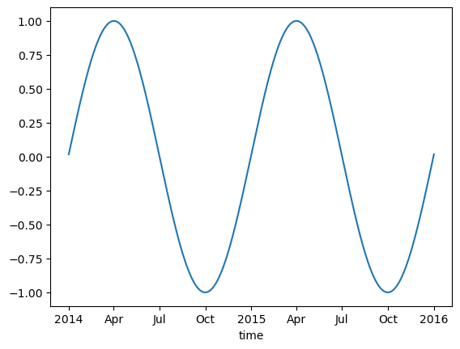

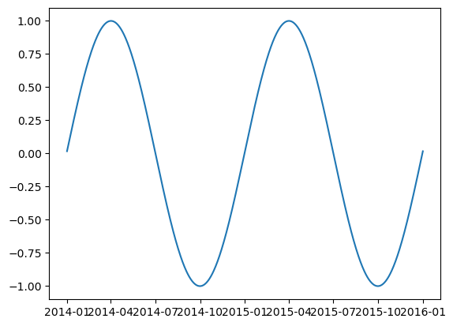

```python
import pandas as pd
import numpy as np
import xarray as xr
import matplotlib.pyplot as plt
%matplotlib inline


two_years = pd.date_range(start='2014-01-01', end='2016-01-01', freq='D')
fake_data = np.sin(2 *np.pi *two_years.dayofyear / 365)

da = xr.DataArray( fake_data,
                  dims=['time'],
                 coords = {'time': two_years})
da.plot()

fig = plt.figure();
plt.plot(two_years,fake_data);
da;
```

# Build a multidimentional DataArray and Dataset

We made up some data in the simple example. Also, did you notice it's just one dimensional? Let's go through the excercise by building a multidimentional dataset.

We are going to start with some data that is just a bunch of normal numpy arrays, so we need to load numpy as well as xarray

### credit

This lesson is from Abernathy's book: (https://earth-env-data-science.github.io/lectures/xarray/xarray_intro.html).

```python
# import xarray, numpy and matplotlib
import xarray as xr
import numpy as np
import matplotlib.pyplot as plt
%matplotlib inline
```

# Example: ARGO float

[figure not shown]

Let's start by loading some real data. This is ARGO float data that contains temperature and salinity data {What is an Argo float? how does it take data?}. Those data are in the form of numpy arrays, or matricies. So, again, rows and columns. Let's draw on the board what the rows and columns are. They have coordinates like time, depth, latitude, longitude. Stuff you would expect to describe data collected in the ocean.

Right now, when we load the data, it's going to be a collection of numpy arrays. They are all seperate objects, and what we'd like to do is stitch them together in a sensible way. To this we are going to create a DataArray, then a Dataset.

```python
argo_data = np.load('./data/argo_float_4901412.npz')
# argo_data = np.load('../../01_python_intro/assignments/argo_float_4901412.npz')

list(argo_data.keys())
# dict(argo_data)
# type conversion... int("1"), str(1)
```

```
['S', 'T', 'levels', 'lon', 'date', 'P', 'lat']
```

They are in this container because of how they are saved. Let's break each component out into it's own numpy array

```python
S = argo_data['S']
T = argo_data['T']
P = argo_data['P']
levels = argo_data['levels']
lon = argo_data['lon']
lat = argo_data['lat']
date = argo_data['date']

# %whos

for key in argo_data:
    print( key, ' shape is: ', argo_data[key].shape)
```

```
S  shape is:  (78, 75)
T  shape is:  (78, 75)
levels  shape is:  (78,)
lon  shape is:  (75,)
date  shape is:  (75,)
P  shape is:  (78, 75)
lat  shape is:  (75,)
```

Remember from the previous notebook.

The `DataArray` has these key properties:

- `data`: N-dimensional array (NumPy or dask) holding the array’s values, i.e. your actual data,
- `dims`: dimension names for each axis, just the names, like 'latitude' or 'longitude' or 'time'
- `coords`: dictionary-like container of arrays that label each point, i.e. the actual values of each axis like time or latitue or something
- `attrs`: ordered dictionary holding metadata, or 'attributes', like the data units, person who collected, any of that stuff

Let's take the salinity `S` and create a DataArray for it

```python
da_salinity = xr.DataArray(S, dims=['level', 'date'], coords={'level': levels, 'date': date})
# da_salinity = xr.DataArray(S, coords={'level': levels, 'date': date})
# da_salinity = xr.DataArray(S, dims=['level', 'date'])

da_salinity
```

```
<xarray.DataArray (level: 78, date: 75)> Size: 47kB
array([[35.6389389 , 35.51495743, 35.57297134, ..., 35.82093811,
        35.77793884, 35.66891098],
       [35.63393784, 35.5219574 , 35.57397079, ..., 35.81093216,
        35.58389664, 35.66791153],
       [35.6819458 , 35.52595901, 35.57297134, ..., 35.79592896,
        35.66290665, 35.66591263],
       ...,
       [34.91585922, 34.92390442, 34.92390442, ..., 34.93481064,
        34.94081116, 34.94680786],
       [34.91585922, 34.92390442, 34.92190552, ..., 34.93280792,
        34.93680954, 34.94380951],
       [34.91785812, 34.92390442, 34.92390442, ...,         nan,
        34.93680954,         nan]], shape=(78, 75))
Coordinates:
  * level    (level) int64 624B 0 1 2 3 4 5 6 7 8 ... 69 70 71 72 73 74 75 76 77
  * date     (date) datetime64[ns] 600B 2012-07-13T22:33:06.019200 ... 2014-0...
```

Ok, this is like the 1D fake bird data we made before, but now it's real 2D salinity data from the ocean.

Let's see what xarray does if we ask it to make a simple plot:

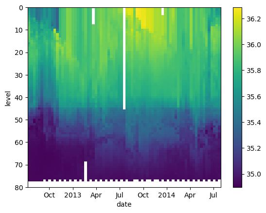

```python
da_salinity.plot()

# lets switch the axis order so depth goes down
plt.ylim([80, 0]);
```

Nice! That is sort of amazing. Xarray knew that the salinity data is 2d - so by default it smartly made a pcolor plot (not a line plot or something). It also knew that time is on the x axis, and the 'levels' (depth) are on the y axis because the dimensions match. It also labeled out axis and formatted the dates.

But we aren't done with out DataArray yet. Remember the four parts of a DataArray? `data`, `dims`, `coords`, `attrs`. We can add other important information into the `attrs` part of the DataArray. Can you think of some important info?

```python
# add some attributes describing the data and units

da_salinity.attrs['units'] = 'PSU'
da_salinity.attrs['standard_name'] = 'sea_water_salinity'
da_salinity
```

```
<xarray.DataArray (level: 78, date: 75)> Size: 47kB
array([[35.6389389 , 35.51495743, 35.57297134, ..., 35.82093811,
        35.77793884, 35.66891098],
       [35.63393784, 35.5219574 , 35.57397079, ..., 35.81093216,
        35.58389664, 35.66791153],
       [35.6819458 , 35.52595901, 35.57297134, ..., 35.79592896,
        35.66290665, 35.66591263],
       ...,
       [34.91585922, 34.92390442, 34.92390442, ..., 34.93481064,
        34.94081116, 34.94680786],
       [34.91585922, 34.92390442, 34.92190552, ..., 34.93280792,
        34.93680954, 34.94380951],
       [34.91785812, 34.92390442, 34.92390442, ...,         nan,
        34.93680954,         nan]], shape=(78, 75))
Coordinates:
  * level    (level) int64 624B 0 1 2 3 4 5 6 7 8 ... 69 70 71 72 73 74 75 76 77
  * date     (date) datetime64[ns] 600B 2012-07-13T22:33:06.019200 ... 2014-0...
Attributes:
    units:          PSU
    standard_name:  sea_water_salinity
```

```
(80.0, 0.0)
```

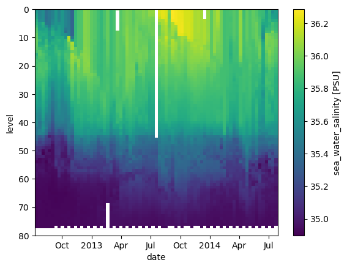

```python
# make the default plot again:

da_salinity.plot()

plt.ylim([80, 0])
```

# Datasets

xarray datasets can hold multiple DataArrays. This makes particular sense if the data in those multiple DataArrays share dimensions and coordinates.

In our ARGO float example, both the Temperature and Salinity share the same dims and cords. So let's put them together into one dataset that holds all out float observational data.

The Dataset constructor takes three arguments:

- `data_vars` should be a dictionary with each key as the name of the variable and each can be an already constructed DataArray, or a tuple that looks like this `(dims, data[, attrs])`
- `coords` should be a dictionary of the same form as data_vars.
- `attrs` should be a dictionary.

So here is an example for our argo data:

```python
# A dictionary of data variables that specifies the dimensions and data as a tuple
data_vars = {'salinity':    (('level', 'date'), S),
             'temperature': (('level', 'date'), T),
             'pressure':    (('level', 'date'), P)}

# A dictionary of coordinates
coords={'level': levels, 'date': date}

argo = xr.Dataset(data_vars, coords)

# print
argo
```

```
<xarray.Dataset> Size: 142kB
Dimensions:      (level: 78, date: 75)
Coordinates:
  * level        (level) int64 624B 0 1 2 3 4 5 6 7 ... 70 71 72 73 74 75 76 77
  * date         (date) datetime64[ns] 600B 2012-07-13T22:33:06.019200 ... 20...
Data variables:
    salinity     (level, date) float64 47kB 35.64 35.51 35.57 ... nan 34.94 nan
    temperature  (level, date) float64 47kB 18.97 18.44 19.1 ... nan 3.714 nan
    pressure     (level, date) float64 47kB 6.8 6.1 6.5 5.0 ... nan 2e+03 nan
```

Let's talk through what all those parts are telling us when we print out `argo`.

What about the latitude and longitude? Those seem important and we'd like to use them for plotting and analysis later. They should be coordinates right? They should be the same size as one of the existing coordinates, either level or date. what do you think?

to add a new coordinate we can use:

```python
argo.coords['lon'] = lon  # or argo_data['lon']

argo

del argo['lon'];
```

What we just did was add a whole new coordinate `lon`. But actually we know that each `lon` point is at a particular `date` location. So actually we can associate `lon` and `date`. To do that we set the dim of out new coord `lon` to be `date`. We can do the same for `lat`.

```python
argo.coords['lon'] = ('date', lon)
argo.coords['lat'] = ('date', lat)
argo
```

```
<xarray.Dataset> Size: 143kB
Dimensions:      (level: 78, date: 75)
Coordinates:
  * level        (level) int64 624B 0 1 2 3 4 5 6 7 ... 70 71 72 73 74 75 76 77
  * date         (date) datetime64[ns] 600B 2012-07-13T22:33:06.019200 ... 20...
    lon          (date) float64 600B -39.13 -37.28 -36.9 ... -34.11 -34.38
    lat          (date) float64 600B 47.19 46.72 46.45 ... 42.6 42.46 42.38
Data variables:
    salinity     (level, date) float64 47kB 35.64 35.51 35.57 ... nan 34.94 nan
    temperature  (level, date) float64 47kB 18.97 18.44 19.1 ... nan 3.714 nan
    pressure     (level, date) float64 47kB 6.8 6.1 6.5 5.0 ... nan 2e+03 nan
```

# Working with labeled data

We've built our nice dataset for the ARGO float. It has Temperature, salinity and pressure data. Those data also have label dimensions / coordinates that include level, date, lat, and lon.

Now we are going to start to see some of the power of Xarray and how those labeled dimensions / coordinates let us make our analysis easier

## Selecting data (indexing)

Let's say we want to look at some subset of the temperature data (just a slice). We can use standard numpy notation to do this by indicating the number of the row and column we are interested in. Let's say we want to look at the second row and all columns ( so this is like a timeseries at a particular level)

using standard numpy indexing this would look like:

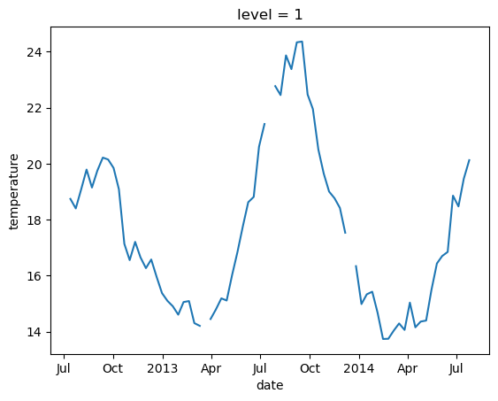

```python
# plot temp at level 1 over time:
argo.temperature[1,:].plot()
# argo.temperature.sel(levels = 5).plot()
```

what about a particular depth profile?

in standard numpy indexing:

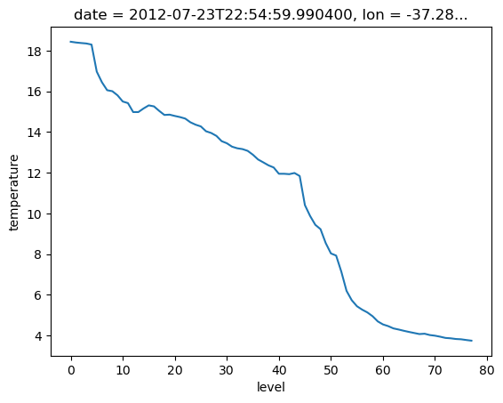

```python
# plot temp vs level for profile 1
argo.temperature[:,1].plot()
```

That seems easy enough. But let's say you want to look at the temperature profile from a particular day. How are you going to do that? Well, you'd need to use the `date` dimension, look up the date you want, find it's index (meaning the number/position it comes in the list of dates) then put that index into the `argo.temperature[:,1].plot()` line.

This isn't impossible. This is the kind of thing you do all the time in matlab. It's annoying and takes a few lines of code.

But xarray solves this problem! using the `.sel()` method you can 'select' a part of your data based on the label.

Here is how it works. let's get the profile on Oct 22 2012 by selecting based on the dimension `date`:

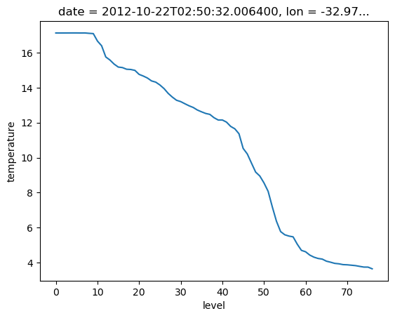

```python
# plot the temp profile on a particular day using .sel()

argo.temperature.sel(date='10-22-2012', method='nearest').plot()
# argo.temperature.sel(date='10-23-2012', method='nearest').plot()

# argo.temperature.sel(date='10-22-2012').plot(y='level')
```

# Slicing data

We can also grab a bunch of days. Grabbing a bunch of consecutive data is typically called 'slicing'. We have to tell xarray that we want a slice of the `date` dimension. Again, this is new syntax, so don't be worried that you don't know it. You'll learn as you go from examples and from reading the documents for different packages.

let's get a couple months around our previous profile:

```
(80.0, 0.0)
```

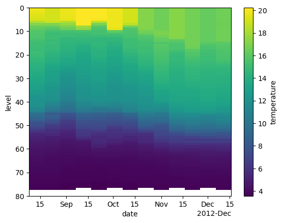

```python
# select a time range using .sel() with the slice() argument

argo.temperature.sel( date = slice('08-10-2012','12-10-2012') ).plot()

plt.ylim([80,0])

# plt.gcf().autofmt_xdate()
```

You can also use `.sel()` on the whole dataset to, for example, grab all your data from one day:

```python
argo_one_day = argo.sel(date='10-22-2012')
# argo_one_day = argo.sel(lon='-37.053') # doesn't work

argo_one_day
```

```
<xarray.Dataset> Size: 3kB
Dimensions:      (level: 78, date: 1)
Coordinates:
  * level        (level) int64 624B 0 1 2 3 4 5 6 7 ... 70 71 72 73 74 75 76 77
  * date         (date) datetime64[ns] 8B 2012-10-22T02:50:32.006400
    lon          (date) float64 8B -32.97
    lat          (date) float64 8B 44.13
Data variables:
    salinity     (level, date) float64 624B 35.47 35.47 35.47 ... 34.92 nan
    temperature  (level, date) float64 624B 17.13 17.13 17.13 ... 3.639 nan
    pressure     (level, date) float64 624B 6.4 10.3 15.4 ... 1.951e+03 nan
```

# Math

we can do any normal math on these DataArrays and Datasets:

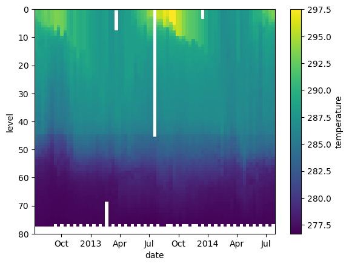

```python
temp_kelvin = argo.temperature + 273.15

temp_kelvin.plot()
plt.ylim([80,0])

argo['temp_kelvin'] = temp_kelvin;
# argo
```

you can combine DataArrays of the same size to get derived products like buoyancy:

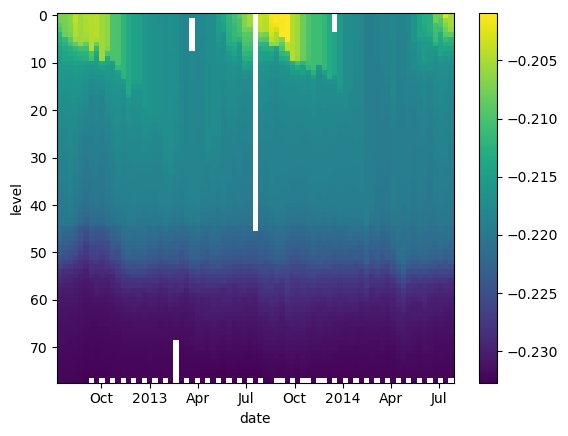

```python
g = 9.8
alpha = 2e-4
beta = -7e-4

buoyancy = g * (alpha * argo.temperature + beta * argo.salinity)

buoyancy.plot()

# plt.ylim([80,0])
plt.gca().invert_yaxis()

argo['buoyancy'] = g * (alpha * argo.temperature + beta * argo.salinity);
# argo
```

we can do standard numpy math stuff like means, standard deviations, etc on dimensions.

We can average the whole dataset. xarray is smart, and it's going to average each of the data variabiles independantly:

```python
argo_mean = argo.mean(dim='date')

argo_mean
```

```
<xarray.Dataset> Size: 4kB
Dimensions:      (level: 78)
Coordinates:
  * level        (level) int64 624B 0 1 2 3 4 5 6 7 ... 70 71 72 73 74 75 76 77
Data variables:
    salinity     (level) float64 624B 35.91 35.9 35.9 35.9 ... 34.94 34.94 34.93
    temperature  (level) float64 624B 17.6 17.57 17.51 ... 3.789 3.73 3.662
    pressure     (level) float64 624B 6.435 10.57 15.54 ... 1.95e+03 1.999e+03
    temp_kelvin  (level) float64 624B 290.8 290.7 290.7 ... 276.9 276.9 276.8
    buoyancy     (level) float64 624B -0.2118 -0.2118 -0.212 ... -0.2324 -0.2325
```

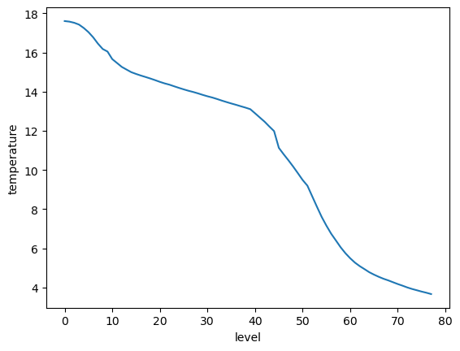

```python
argo_mean.temperature.plot()
# plt.plot(argo_mean.pressure,argo_mean.temperature)
```

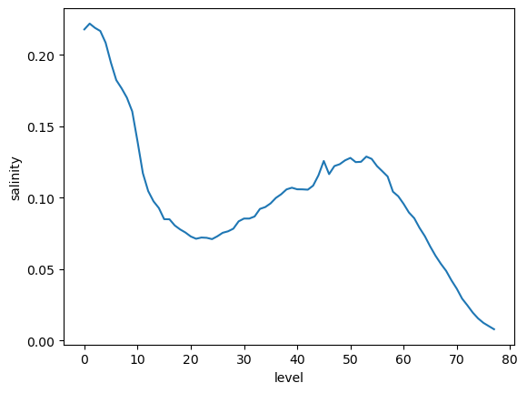

```python
# get the standard deviation:
argo_std = argo.std(dim='date')

# argo_std.temperature.plot()
argo_std.salinity.plot()
```

There are a lot more cool math/analysis functions we can do with xarray. We will see more of them later on.

The end...

# Breakout / exercise 02

# Exercise - plotting and stats

First load what we need and create a dataset (the code below is exactly what we did in the class, compressed into one cell).

```python
import xarray as xr
import numpy as np
import matplotlib.pyplot as plt
%matplotlib inline

argo_data = np.load('./data/argo_float_4901412.npz')
# argo_data = np.load('../data/01_python_intro/assignments/argo_float_4901412.npz')

data_vars = {'salinity':    (('level', 'date'), argo_data["S"]),
             'temperature': (('level', 'date'), argo_data["T"]),
             'pressure':    (('level', 'date'), argo_data["P"])}

# A dictionary of coordinates
coords = coords={'level': argo_data["levels"], 'date': argo_data["date"]}

argo = xr.Dataset(data_vars, coords)
```

In the lesson, we took the standard deviation of every variable in a DataSet and plotted them like this:

```
argo_std = argo.std(dim='date')

argo_std.temperature.plot()
```

However, in python, functions can sometimes be chained together. For example:

```
import numpy as np

x = np.random.rand(10, 10)  # Create an array of random numbers
x.mean(axis=1).min()  # Compute the mean along one axis, then the minimum.
```

So do we need to create the variable `argo_std` before plotting? Could we do the standard deviation and plot in one line of code? Have a go...

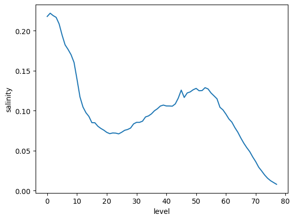

```python
# argo.salinity.plot()
argo.salinity.std(dim='date').plot()
```

How do you find the maximum standard deviation in salinity? Again, try in one line of code. Does the answer match your expectation from the plot above?

```python
argo.salinity.std(dim='date').max()
```

```
<xarray.DataArray 'salinity' ()> Size: 8B
array(0.22181831)
```